# Проект: Восстановление золота из руды.

Автор: Семен Лимонов.

Задача — разработать прототип модели машинного обучения для эффективной работы промышленных предприятий. Модель должна предсказывать коэффициент восстановления золота из золотосодержащей руды на основе данных с параметрами входящей руды и показателями процесса флотации и очистки. Модель поможет оптимизировать производство, чтобы не запускать предприятие с убыточными характеристиками.

Метрика качества - sMAPE (англ. Symmetric Mean Absolute Percentage Error, «симметричное среднее абсолютное процентное отклонение») для оценки эффективности обогащения отдельно чернового (rougher) и финального (final) концентрата. Итоговая метрика рассчитывается по формуле: Итоговое sMAPE = 25% sMAPE (rougher) + 75% sMAPE (final).

Описание данных:

Технологический процесс

- Rougher feed — исходное сырье
- Rougher additions (или reagent additions) — флотационные реагенты Xanthate, Sulphate, Depressant:
  - Xanthate — ксантогенат (промотер, или активатор флотации)
  - Sulphate — сульфат (на данном производстве сульфид натрия)
  - Depressant — депрессант (силикат натрия)
- Rougher process (англ. «грубый процесс») — флотация
- Rougher tails — отвальные хвосты
- Float banks — флотационная установка
- Cleaner process — очистка
- Rougher Au — черновой концентрат золота
- Final Au — финальный концентрат золота

Параметры этапов

- air amount — объём воздуха
- fluid levels — уровень жидкости
- feed size — размер гранул сырья
- feed rate — скорость подачи

Наименование признаков: [этап].[тип_параметра].[название_параметра]

Пример: rougher.input.feed_ag

Возможные значения для блока [этап]:

- `rougher` — флотация
- `primary_cleaner` — первичная очистка
- `secondary_cleaner` — вторичная очистка
- `final` — финальные характеристики

Возможные значения для блока [тип_параметра]:

- `input` — параметры сырья
- `output` — параметры продукта
- `state` — параметры, характеризующие текущее состояние этапа
- `calculation` — расчётные характеристики

Данные содержатся в трёх файлах:

- gold_recovery_train_new.csv — обучающая выборка
- gold_recovery_test_new.csv — тестовая выборка
- gold_recovery_full_new.csv — исходные данные

Планируемые этапы исследования:

1. Подготовка данных (открытие файла с данными, изучение общей информации, проверка расчета целевого показателя recovery, анализ различий обучающей и тестовой выборки, предобработка данных).
2. Исследовательский анализ данных (динамика концентрации металлов, в том числе суммарной, на разных этапах очистки, сравнение распределения размеров гранул в обучающей и тестовой выборках).
3. Выбор лучшей модели с подбором гиперпараметров с использованием обучающей выбрки методом кросс-валидации, проверка лучшей модели на тестовой выборке и проверка на адекватность (sanity check).
4. Общий вывод.

## Подготовка данных.

### Загрузка данных и первичное изучение.

```python
# Импортируем необходимые бибилиотеки

import pandas as pd
import numpy as np
import matplotlib.pyplot as plt
import seaborn as sns
from numpy.random import RandomState

from sklearn.linear_model import (LinearRegression,
                                  Lasso)
from sklearn.ensemble import (GradientBoostingRegressor)
from sklearn.tree import DecisionTreeRegressor
from sklearn.dummy import DummyRegressor


from sklearn.preprocessing import (MinMaxScaler, MaxAbsScaler)
from sklearn.model_selection import (GridSearchCV,
                                     RandomizedSearchCV)
from sklearn.metrics import (mean_absolute_error,
                             make_scorer)

from IPython.display import display
pd.set_option('display.float_format','{:,.2f}'.format,
              'display.max_rows', 100,
              'display.max_columns', None)
```

```python
# Откроем файл с данными и создадим dataframe, учитывая разделитель данных в файле
# и разделитель целой и дробной части чисел
df_train = pd.read_csv('/datasets/gold_recovery_train_new.csv', sep=',', decimal='.')
df_test = pd.read_csv('/datasets/gold_recovery_test_new.csv', sep=',', decimal='.')
df_full = pd.read_csv('/datasets/gold_recovery_full_new.csv', sep=',', decimal='.')
```

```python
# выведем на экран общую информацию
def info_descr (df):
    display(df.info())
    display(df.head(2))
    display(df.describe())
    print('Доля пропусков:')
    display(df.isna().mean().sort_values(ascending=False)*100)
```

```python
info_descr(df_train)
```

```
<class 'pandas.core.frame.DataFrame'>
RangeIndex: 14149 entries, 0 to 14148
Data columns (total 87 columns):
 #   Column                                              Non-Null Count  Dtype
---  ------                                              --------------  -----
 0   date                                                14149 non-null  object
 1   final.output.concentrate_ag                         14148 non-null  float64
 2   final.output.concentrate_pb                         14148 non-null  float64
 3   final.output.concentrate_sol                        13938 non-null  float64
 4   final.output.concentrate_au                         14149 non-null  float64
 5   final.output.recovery                               14149 non-null  float64
 6   final.output.tail_ag                                14149 non-null  float64
 7   final.output.tail_pb                                14049 non-null  float64
 8   final.output.tail_sol                               14144 non-null  float64
 9   final.output.tail_au                                14149 non-null  float64
```

[output cut: 79 more lines]

```
None
```

|  | date | final.output.concentrate_ag | final.output.concentrate_pb | final.output.concentrate_sol | final.output.concentrate_au | final.output.recovery | final.output.tail_ag | final.output.tail_pb | final.output.tail_sol | final.output.tail_au | primary_cleaner.input.sulfate | primary_cleaner.input.depressant | primary_cleaner.input.feed_size | primary_cleaner.input.xanthate | primary_cleaner.output.concentrate_ag | primary_cleaner.output.concentrate_pb | primary_cleaner.output.concentrate_sol | primary_cleaner.output.concentrate_au | primary_cleaner.output.tail_ag | primary_cleaner.output.tail_pb | primary_cleaner.output.tail_sol | primary_cleaner.output.tail_au | primary_cleaner.state.floatbank8_a_air | primary_cleaner.state.floatbank8_a_level | primary_cleaner.state.floatbank8_b_air | primary_cleaner.state.floatbank8_b_level | primary_cleaner.state.floatbank8_c_air | primary_cleaner.state.floatbank8_c_level | primary_cleaner.state.floatbank8_d_air | … |
| --- | --- | --- | --- | --- | --- | --- | --- | --- | --- | --- | --- | --- | --- | --- | --- | --- | --- | --- | --- | --- | --- | --- | --- | --- | --- | --- | --- | --- | --- | --- |
| 0 | 2016-01-15 00:00:00 | 6.06 | 9.89 | 5.51 | 42.19 | 70.54 | 10.41 | 0.90 | 16.90 | 2.14 | 127.09 | 10.13 | 7.25 | 0.99 | 8.55 | 10.39 | 19.53 | 34.17 | 14.94 | 2.53 | 7.48 | 2.11 | 1,549.78 | -498.91 | 1,551.43 | -516.40 | 1,549.87 | -498.67 | 1,554.37 | … |
| 1 | 2016-01-15 01:00:00 | 6.03 | 9.97 | 5.26 | 42.70 | 69.27 | 10.46 | 0.93 | 16.63 | 2.22 | 125.63 | 10.30 | 7.25 | 1.00 | 8.56 | 10.50 | 19.37 | 34.12 | 16.25 | 3.05 | 6.73 | 2.35 | 1,576.17 | -500.90 | 1,575.95 | -499.87 | 1,575.99 | -499.32 | 1,574.48 | … |

|  | final.output.concentrate_ag | final.output.concentrate_pb | final.output.concentrate_sol | final.output.concentrate_au | final.output.recovery | final.output.tail_ag | final.output.tail_pb | final.output.tail_sol | final.output.tail_au | primary_cleaner.input.sulfate | primary_cleaner.input.depressant | primary_cleaner.input.feed_size | primary_cleaner.input.xanthate | primary_cleaner.output.concentrate_ag | primary_cleaner.output.concentrate_pb | primary_cleaner.output.concentrate_sol | primary_cleaner.output.concentrate_au | primary_cleaner.output.tail_ag | primary_cleaner.output.tail_pb | primary_cleaner.output.tail_sol | primary_cleaner.output.tail_au | primary_cleaner.state.floatbank8_a_air | primary_cleaner.state.floatbank8_a_level | primary_cleaner.state.floatbank8_b_air | primary_cleaner.state.floatbank8_b_level | primary_cleaner.state.floatbank8_c_air | primary_cleaner.state.floatbank8_c_level | primary_cleaner.state.floatbank8_d_air | primary_cleaner.state.floatbank8_d_level | … |
| --- | --- | --- | --- | --- | --- | --- | --- | --- | --- | --- | --- | --- | --- | --- | --- | --- | --- | --- | --- | --- | --- | --- | --- | --- | --- | --- | --- | --- | --- | --- |
| count | 14,148.00 | 14,148.00 | 13,938.00 | 14,149.00 | 14,149.00 | 14,149.00 | 14,049.00 | 14,144.00 | 14,149.00 | 14,129.00 | 14,117.00 | 14,149.00 | 14,049.00 | 14,149.00 | 14,063.00 | 13,863.00 | 14,149.00 | 14,148.00 | 14,134.00 | 14,103.00 | 14,149.00 | 14,145.00 | 14,148.00 | 14,145.00 | 14,148.00 | 14,147.00 | 14,148.00 | 14,146.00 | 14,148.00 | … |
| mean | 5.14 | 10.13 | 9.20 | 44.00 | 66.52 | 9.61 | 2.60 | 10.51 | 2.92 | 133.32 | 8.87 | 7.32 | 0.89 | 8.20 | 9.59 | 10.11 | 32.39 | 16.30 | 3.44 | 7.53 | 3.84 | 1,608.00 | -488.78 | 1,608.61 | -489.17 | 1,608.88 | -489.61 | 1,542.19 | -483.46 | … |
| std | 1.37 | 1.65 | 2.79 | 4.91 | 10.30 | 2.32 | 0.97 | 3.00 | 0.90 | 39.43 | 3.36 | 0.61 | 0.37 | 2.01 | 2.69 | 4.06 | 5.80 | 3.74 | 1.49 | 2.13 | 1.60 | 128.39 | 35.70 | 131.11 | 33.60 | 134.27 | 35.62 | 278.32 | 47.10 | … |
| min | 0.00 | 0.00 | 0.00 | 0.00 | 0.00 | 0.00 | 0.00 | 0.00 | 0.00 | 0.00 | 0.00 | 1.08 | 0.00 | 0.00 | 0.00 | 0.00 | 0.00 | 0.00 | 0.00 | 0.00 | 0.00 | 0.01 | -798.64 | 0.01 | -740.12 | 0.02 | -799.80 | 0.01 | -799.79 | … |
| 25% | 4.21 | 9.30 | 7.48 | 43.28 | 62.55 | 8.00 | 1.91 | 8.81 | 2.37 | 107.01 | 6.04 | 6.96 | 0.61 | 7.11 | 8.33 | 7.49 | 30.86 | 13.87 | 2.42 | 6.33 | 2.87 | 1,595.70 | -500.29 | 1,558.96 | -500.38 | 1,549.87 | -500.60 | 1,452.68 | -500.46 | … |
| 50% | 4.99 | 10.30 | 8.85 | 44.87 | 67.43 | 9.48 | 2.59 | 10.51 | 2.85 | 133.02 | 8.04 | 7.29 | 0.89 | 8.23 | 9.93 | 9.73 | 33.23 | 15.80 | 3.22 | 7.71 | 3.51 | 1,601.82 | -499.91 | 1,601.82 | -499.94 | 1,601.57 | -499.87 | 1,600.17 | -499.83 | … |
| 75% | 5.86 | 11.17 | 10.49 | 46.17 | 72.35 | 11.00 | 3.24 | 11.93 | 3.43 | 159.83 | 11.52 | 7.70 | 1.10 | 9.50 | 11.31 | 13.05 | 35.33 | 18.45 | 4.25 | 8.91 | 4.49 | 1,699.72 | -499.38 | 1,700.22 | -499.39 | 1,700.46 | -498.80 | 1,699.36 | -498.48 | … |
| max | 16.00 | 17.03 | 18.12 | 52.76 | 100.00 | 19.55 | 5.64 | 22.32 | 8.20 | 250.13 | 20.05 | 10.47 | 2.51 | 16.08 | 17.08 | 22.28 | 45.93 | 29.46 | 9.63 | 20.62 | 17.79 | 2,079.53 | -330.13 | 2,114.91 | -347.35 | 2,013.16 | -346.65 | 2,398.90 | -30.60 | … |

```
Доля пропусков:
```

```
secondary_cleaner.output.tail_sol                    11.34
rougher.state.floatbank10_e_air                       3.08
rougher.input.floatbank11_xanthate                    3.02
primary_cleaner.output.concentrate_sol                2.02
secondary_cleaner.state.floatbank2_a_air              1.53
final.output.concentrate_sol                          1.49
rougher.input.feed_size                               1.02
primary_cleaner.input.xanthate                        0.71
rougher.input.feed_pb                                 0.71
final.output.tail_pb                                  0.71
primary_cleaner.output.concentrate_pb                 0.61
rougher.input.feed_sol                                0.55
primary_cleaner.output.tail_sol                       0.33
rougher.input.floatbank11_sulfate                     0.25
primary_cleaner.input.depressant                      0.23
rougher.input.floatbank10_sulfate                     0.20
rougher.output.concentrate_sol                        0.16
secondary_cleaner.state.floatbank2_b_air              0.15
primary_cleaner.input.sulfate                         0.14
primary_cleaner.output.tail_pb                        0.11
secondary_cleaner.output.tail_pb                      0.07
rougher.input.feed_rate                               0.06
rougher.input.floatbank10_xanthate                    0.06
secondary_cleaner.state.floatbank4_a_air              0.04
final.output.tail_sol                                 0.04
secondary_cleaner.state.floatbank3_a_air              0.03
primary_cleaner.state.floatbank8_a_air                0.03
primary_cleaner.state.floatbank8_b_air                0.03
primary_cleaner.state.floatbank8_d_air                0.02
primary_cleaner.state.floatbank8_c_air                0.01
secondary_cleaner.output.tail_ag                      0.01
secondary_cleaner.state.floatbank6_a_air              0.01
rougher.state.floatbank10_b_level                     0.01
rougher.state.floatbank10_b_air                       0.01
rougher.state.floatbank10_c_level                     0.01
rougher.state.floatbank10_c_air                       0.01
secondary_cleaner.state.floatbank3_a_level            0.01
secondary_cleaner.state.floatbank2_a_level            0.01
secondary_cleaner.state.floatbank2_b_level            0.01
rougher.state.floatbank10_a_air                       0.01
```

[output cut: 33 more lines]

```
rougher.calculation.au_pb_ratio                       0.00
rougher.input.feed_ag                                 0.00
rougher.input.feed_au                                 0.00
rougher.state.floatbank10_f_level                     0.00
rougher.state.floatbank10_f_air                       0.00
rougher.state.floatbank10_e_level                     0.00
rougher.state.floatbank10_d_level                     0.00
rougher.state.floatbank10_d_air                       0.00
rougher.output.concentrate_ag                         0.00
rougher.output.concentrate_pb                         0.00
rougher.output.concentrate_au                         0.00
rougher.output.recovery                               0.00
rougher.output.tail_pb                                0.00
date                                                  0.00
dtype: float64
```

Вывод: Обучающая выборка состоит из 87 столбцов и 14149 строк. Имеются пропуски в некоторых столбцах до 3%, по одному параметру пропусков - 11%.

```python
info_descr(df_test)
```

```
<class 'pandas.core.frame.DataFrame'>
RangeIndex: 5290 entries, 0 to 5289
Data columns (total 53 columns):
 #   Column                                      Non-Null Count  Dtype
---  ------                                      --------------  -----
 0   date                                        5290 non-null   object
 1   primary_cleaner.input.sulfate               5286 non-null   float64
 2   primary_cleaner.input.depressant            5285 non-null   float64
 3   primary_cleaner.input.feed_size             5290 non-null   float64
 4   primary_cleaner.input.xanthate              5286 non-null   float64
 5   primary_cleaner.state.floatbank8_a_air      5290 non-null   float64
 6   primary_cleaner.state.floatbank8_a_level    5290 non-null   float64
 7   primary_cleaner.state.floatbank8_b_air      5290 non-null   float64
 8   primary_cleaner.state.floatbank8_b_level    5290 non-null   float64
 9   primary_cleaner.state.floatbank8_c_air      5290 non-null   float64
```

[output cut: 45 more lines]

```
None
```

|  | date | primary_cleaner.input.sulfate | primary_cleaner.input.depressant | primary_cleaner.input.feed_size | primary_cleaner.input.xanthate | primary_cleaner.state.floatbank8_a_air | primary_cleaner.state.floatbank8_a_level | primary_cleaner.state.floatbank8_b_air | primary_cleaner.state.floatbank8_b_level | primary_cleaner.state.floatbank8_c_air | primary_cleaner.state.floatbank8_c_level | primary_cleaner.state.floatbank8_d_air | primary_cleaner.state.floatbank8_d_level | rougher.input.feed_ag | rougher.input.feed_pb | rougher.input.feed_rate | rougher.input.feed_size | rougher.input.feed_sol | rougher.input.feed_au | rougher.input.floatbank10_sulfate | rougher.input.floatbank10_xanthate | rougher.input.floatbank11_sulfate | rougher.input.floatbank11_xanthate | rougher.state.floatbank10_a_air | rougher.state.floatbank10_a_level | rougher.state.floatbank10_b_air | rougher.state.floatbank10_b_level | rougher.state.floatbank10_c_air | rougher.state.floatbank10_c_level | … |
| --- | --- | --- | --- | --- | --- | --- | --- | --- | --- | --- | --- | --- | --- | --- | --- | --- | --- | --- | --- | --- | --- | --- | --- | --- | --- | --- | --- | --- | --- | --- |
| 0 | 2016-09-01 00:59:59 | 210.80 | 14.99 | 8.08 | 1.01 | 1,398.98 | -500.23 | 1,399.14 | -499.92 | 1,400.10 | -500.70 | 1,399.00 | -499.49 | 13.13 | 5.64 | 489.79 | 62.71 | 42.02 | 12.08 | 16.92 | 6.15 | 16.87 | 6.15 | 1,001.85 | -350.30 | 1,249.74 | -399.11 | 1,249.75 | -399.40 | … |
| 1 | 2016-09-01 01:59:59 | 215.39 | 14.99 | 8.08 | 0.99 | 1,398.78 | -500.06 | 1,398.06 | -499.78 | 1,396.15 | -499.24 | 1,399.51 | -500.42 | 13.04 | 5.53 | 490.10 | 61.96 | 41.19 | 11.92 | 17.00 | 6.00 | 17.00 | 6.00 | 998.69 | -350.43 | 1,248.40 | -399.95 | 1,249.51 | -399.63 | … |

|  | primary_cleaner.input.sulfate | primary_cleaner.input.depressant | primary_cleaner.input.feed_size | primary_cleaner.input.xanthate | primary_cleaner.state.floatbank8_a_air | primary_cleaner.state.floatbank8_a_level | primary_cleaner.state.floatbank8_b_air | primary_cleaner.state.floatbank8_b_level | primary_cleaner.state.floatbank8_c_air | primary_cleaner.state.floatbank8_c_level | primary_cleaner.state.floatbank8_d_air | primary_cleaner.state.floatbank8_d_level | rougher.input.feed_ag | rougher.input.feed_pb | rougher.input.feed_rate | rougher.input.feed_size | rougher.input.feed_sol | rougher.input.feed_au | rougher.input.floatbank10_sulfate | rougher.input.floatbank10_xanthate | rougher.input.floatbank11_sulfate | rougher.input.floatbank11_xanthate | rougher.state.floatbank10_a_air | rougher.state.floatbank10_a_level | rougher.state.floatbank10_b_air | rougher.state.floatbank10_b_level | rougher.state.floatbank10_c_air | rougher.state.floatbank10_c_level | rougher.state.floatbank10_d_air | … |
| --- | --- | --- | --- | --- | --- | --- | --- | --- | --- | --- | --- | --- | --- | --- | --- | --- | --- | --- | --- | --- | --- | --- | --- | --- | --- | --- | --- | --- | --- | --- |
| count | 5,286.00 | 5,285.00 | 5,290.00 | 5,286.00 | 5,290.00 | 5,290.00 | 5,290.00 | 5,290.00 | 5,290.00 | 5,290.00 | 5,290.00 | 5,290.00 | 5,290.00 | 5,290.00 | 5,287.00 | 5,289.00 | 5,269.00 | 5,290.00 | 5,285.00 | 5,290.00 | 5,282.00 | 5,265.00 | 5,290.00 | 5,290.00 | 5,290.00 | 5,290.00 | 5,290.00 | 5,290.00 | 5,290.00 | … |
| mean | 174.84 | 8.68 | 7.27 | 1.38 | 1,539.49 | -497.67 | 1,545.17 | -500.27 | 1,527.27 | -498.33 | 1,544.84 | -500.20 | 9.37 | 3.80 | 489.80 | 55.95 | 37.72 | 9.33 | 13.86 | 6.47 | 13.92 | 6.51 | 1,053.40 | -395.73 | 1,318.93 | -475.24 | 1,301.60 | -474.84 | 1,214.85 | … |
| std | 43.03 | 3.07 | 0.61 | 0.64 | 116.80 | 19.95 | 122.22 | 32.97 | 122.54 | 21.96 | 124.77 | 31.05 | 1.93 | 0.95 | 108.04 | 19.08 | 5.49 | 1.62 | 3.35 | 1.07 | 3.22 | 0.89 | 121.14 | 91.09 | 156.45 | 45.65 | 171.27 | 45.86 | 185.76 | … |
| min | 2.57 | 0.00 | 5.65 | 0.00 | 0.00 | -795.32 | 0.00 | -800.00 | 0.00 | -799.96 | 0.00 | -799.79 | 0.57 | 0.27 | 0.00 | 0.05 | 1.39 | 0.57 | 0.00 | 0.00 | 0.00 | 0.01 | -0.04 | -657.95 | -0.72 | -650.25 | -0.06 | -647.54 | -0.99 | … |
| 25% | 147.12 | 6.49 | 6.89 | 0.91 | 1,498.94 | -500.36 | 1,498.97 | -500.70 | 1,473.23 | -501.02 | 1,499.48 | -500.45 | 8.11 | 3.24 | 407.02 | 43.91 | 34.51 | 8.21 | 12.00 | 6.00 | 12.00 | 6.00 | 999.21 | -499.92 | 1,200.87 | -500.26 | 1,199.65 | -500.23 | 1,093.37 | … |
| 50% | 177.83 | 8.05 | 7.25 | 1.20 | 1,585.13 | -499.97 | 1,595.62 | -500.03 | 1,549.59 | -500.02 | 1,594.58 | -500.02 | 9.76 | 3.74 | 499.05 | 50.84 | 37.98 | 9.59 | 14.00 | 6.50 | 14.00 | 6.50 | 1,000.47 | -399.69 | 1,302.25 | -499.84 | 1,300.20 | -499.78 | 1,207.01 | … |
| 75% | 208.13 | 10.03 | 7.60 | 1.80 | 1,602.08 | -499.57 | 1,602.32 | -499.29 | 1,601.14 | -498.99 | 1,600.96 | -499.61 | 10.65 | 4.28 | 575.31 | 62.43 | 41.64 | 10.46 | 16.97 | 7.09 | 16.96 | 7.09 | 1,006.25 | -300.06 | 1,433.96 | -450.75 | 1,406.59 | -451.15 | 1,391.50 | … |
| max | 265.98 | 40.00 | 15.50 | 4.10 | 2,103.10 | -57.20 | 1,813.08 | -142.53 | 1,715.05 | -150.94 | 1,913.26 | -158.95 | 14.41 | 6.91 | 707.36 | 392.49 | 53.48 | 13.73 | 24.28 | 8.91 | 24.28 | 8.62 | 1,423.27 | -273.78 | 1,706.64 | -298.20 | 1,731.02 | -298.04 | 1,775.22 | … |

```
Доля пропусков:
```

```
rougher.input.floatbank11_xanthate           0.47
rougher.input.feed_sol                       0.40
secondary_cleaner.state.floatbank3_a_air     0.17
rougher.input.floatbank11_sulfate            0.15
primary_cleaner.input.depressant             0.09
rougher.input.floatbank10_sulfate            0.09
primary_cleaner.input.xanthate               0.08
primary_cleaner.input.sulfate                0.08
rougher.input.feed_rate                      0.06
secondary_cleaner.state.floatbank2_a_air     0.06
secondary_cleaner.state.floatbank2_b_air     0.04
rougher.input.feed_size                      0.02
secondary_cleaner.state.floatbank2_b_level   0.00
rougher.state.floatbank10_f_level            0.00
rougher.state.floatbank10_f_air              0.00
secondary_cleaner.state.floatbank3_a_level   0.00
secondary_cleaner.state.floatbank2_a_level   0.00
date                                         0.00
rougher.state.floatbank10_e_air              0.00
secondary_cleaner.state.floatbank3_b_air     0.00
secondary_cleaner.state.floatbank3_b_level   0.00
secondary_cleaner.state.floatbank4_a_air     0.00
secondary_cleaner.state.floatbank4_a_level   0.00
secondary_cleaner.state.floatbank4_b_air     0.00
secondary_cleaner.state.floatbank4_b_level   0.00
secondary_cleaner.state.floatbank5_a_air     0.00
secondary_cleaner.state.floatbank5_a_level   0.00
secondary_cleaner.state.floatbank5_b_air     0.00
secondary_cleaner.state.floatbank5_b_level   0.00
secondary_cleaner.state.floatbank6_a_air     0.00
rougher.state.floatbank10_e_level            0.00
rougher.state.floatbank10_b_level            0.00
rougher.state.floatbank10_d_level            0.00
primary_cleaner.state.floatbank8_d_level     0.00
primary_cleaner.input.feed_size              0.00
primary_cleaner.state.floatbank8_a_air       0.00
primary_cleaner.state.floatbank8_a_level     0.00
primary_cleaner.state.floatbank8_b_air       0.00
primary_cleaner.state.floatbank8_b_level     0.00
primary_cleaner.state.floatbank8_c_air       0.00
primary_cleaner.state.floatbank8_c_level     0.00
primary_cleaner.state.floatbank8_d_air       0.00
rougher.input.feed_ag                        0.00
rougher.state.floatbank10_d_air              0.00
rougher.input.feed_pb                        0.00
rougher.input.feed_au                        0.00
rougher.input.floatbank10_xanthate           0.00
rougher.state.floatbank10_a_air              0.00
rougher.state.floatbank10_a_level            0.00
rougher.state.floatbank10_b_air              0.00
rougher.state.floatbank10_c_air              0.00
rougher.state.floatbank10_c_level            0.00
secondary_cleaner.state.floatbank6_a_level   0.00
dtype: float64
```

```python
info_descr(df_full)
```

```
<class 'pandas.core.frame.DataFrame'>
RangeIndex: 19439 entries, 0 to 19438
Data columns (total 87 columns):
 #   Column                                              Non-Null Count  Dtype
---  ------                                              --------------  -----
 0   date                                                19439 non-null  object
 1   final.output.concentrate_ag                         19438 non-null  float64
 2   final.output.concentrate_pb                         19438 non-null  float64
 3   final.output.concentrate_sol                        19228 non-null  float64
 4   final.output.concentrate_au                         19439 non-null  float64
 5   final.output.recovery                               19439 non-null  float64
 6   final.output.tail_ag                                19438 non-null  float64
 7   final.output.tail_pb                                19338 non-null  float64
 8   final.output.tail_sol                               19433 non-null  float64
 9   final.output.tail_au                                19439 non-null  float64
```

[output cut: 79 more lines]

```
None
```

|  | date | final.output.concentrate_ag | final.output.concentrate_pb | final.output.concentrate_sol | final.output.concentrate_au | final.output.recovery | final.output.tail_ag | final.output.tail_pb | final.output.tail_sol | final.output.tail_au | primary_cleaner.input.sulfate | primary_cleaner.input.depressant | primary_cleaner.input.feed_size | primary_cleaner.input.xanthate | primary_cleaner.output.concentrate_ag | primary_cleaner.output.concentrate_pb | primary_cleaner.output.concentrate_sol | primary_cleaner.output.concentrate_au | primary_cleaner.output.tail_ag | primary_cleaner.output.tail_pb | primary_cleaner.output.tail_sol | primary_cleaner.output.tail_au | primary_cleaner.state.floatbank8_a_air | primary_cleaner.state.floatbank8_a_level | primary_cleaner.state.floatbank8_b_air | primary_cleaner.state.floatbank8_b_level | primary_cleaner.state.floatbank8_c_air | primary_cleaner.state.floatbank8_c_level | primary_cleaner.state.floatbank8_d_air | … |
| --- | --- | --- | --- | --- | --- | --- | --- | --- | --- | --- | --- | --- | --- | --- | --- | --- | --- | --- | --- | --- | --- | --- | --- | --- | --- | --- | --- | --- | --- | --- |
| 0 | 2016-01-15 00:00:00 | 6.06 | 9.89 | 5.51 | 42.19 | 70.54 | 10.41 | 0.90 | 16.90 | 2.14 | 127.09 | 10.13 | 7.25 | 0.99 | 8.55 | 10.39 | 19.53 | 34.17 | 14.94 | 2.53 | 7.48 | 2.11 | 1,549.78 | -498.91 | 1,551.43 | -516.40 | 1,549.87 | -498.67 | 1,554.37 | … |
| 1 | 2016-01-15 01:00:00 | 6.03 | 9.97 | 5.26 | 42.70 | 69.27 | 10.46 | 0.93 | 16.63 | 2.22 | 125.63 | 10.30 | 7.25 | 1.00 | 8.56 | 10.50 | 19.37 | 34.12 | 16.25 | 3.05 | 6.73 | 2.35 | 1,576.17 | -500.90 | 1,575.95 | -499.87 | 1,575.99 | -499.32 | 1,574.48 | … |

|  | final.output.concentrate_ag | final.output.concentrate_pb | final.output.concentrate_sol | final.output.concentrate_au | final.output.recovery | final.output.tail_ag | final.output.tail_pb | final.output.tail_sol | final.output.tail_au | primary_cleaner.input.sulfate | primary_cleaner.input.depressant | primary_cleaner.input.feed_size | primary_cleaner.input.xanthate | primary_cleaner.output.concentrate_ag | primary_cleaner.output.concentrate_pb | primary_cleaner.output.concentrate_sol | primary_cleaner.output.concentrate_au | primary_cleaner.output.tail_ag | primary_cleaner.output.tail_pb | primary_cleaner.output.tail_sol | primary_cleaner.output.tail_au | primary_cleaner.state.floatbank8_a_air | primary_cleaner.state.floatbank8_a_level | primary_cleaner.state.floatbank8_b_air | primary_cleaner.state.floatbank8_b_level | primary_cleaner.state.floatbank8_c_air | primary_cleaner.state.floatbank8_c_level | primary_cleaner.state.floatbank8_d_air | primary_cleaner.state.floatbank8_d_level | … |
| --- | --- | --- | --- | --- | --- | --- | --- | --- | --- | --- | --- | --- | --- | --- | --- | --- | --- | --- | --- | --- | --- | --- | --- | --- | --- | --- | --- | --- | --- | --- |
| count | 19,438.00 | 19,438.00 | 19,228.00 | 19,439.00 | 19,439.00 | 19,438.00 | 19,338.00 | 19,433.00 | 19,439.00 | 19,415.00 | 19,402.00 | 19,439.00 | 19,335.00 | 19,439.00 | 19,323.00 | 19,069.00 | 19,439.00 | 19,435.00 | 19,418.00 | 19,377.00 | 19,439.00 | 19,435.00 | 19,438.00 | 19,435.00 | 19,438.00 | 19,437.00 | 19,438.00 | 19,436.00 | 19,438.00 | … |
| mean | 5.17 | 9.98 | 9.50 | 44.08 | 67.05 | 9.69 | 2.71 | 10.58 | 3.04 | 144.62 | 8.82 | 7.31 | 1.02 | 8.44 | 9.83 | 10.49 | 32.12 | 16.15 | 3.44 | 7.97 | 3.91 | 1,589.35 | -491.20 | 1,591.34 | -492.19 | 1,586.67 | -491.98 | 1,542.91 | -488.02 | … |
| std | 1.37 | 1.67 | 2.79 | 5.13 | 10.13 | 2.33 | 0.95 | 2.87 | 0.92 | 44.46 | 3.29 | 0.61 | 0.51 | 2.05 | 2.56 | 3.91 | 5.63 | 3.55 | 1.39 | 2.21 | 1.59 | 129.00 | 32.43 | 131.81 | 33.79 | 136.11 | 32.71 | 246.20 | 43.96 | … |
| min | 0.00 | 0.00 | 0.00 | 0.00 | 0.00 | 0.00 | 0.00 | 0.00 | 0.00 | 0.00 | 0.00 | 1.08 | 0.00 | 0.00 | 0.00 | 0.00 | 0.00 | 0.00 | 0.00 | 0.00 | 0.00 | 0.00 | -798.64 | 0.00 | -800.00 | 0.00 | -799.96 | 0.00 | -799.79 | … |
| 25% | 4.25 | 9.14 | 7.72 | 43.40 | 63.30 | 8.06 | 2.04 | 8.94 | 2.46 | 114.11 | 6.08 | 6.94 | 0.70 | 7.26 | 8.70 | 7.89 | 30.46 | 14.02 | 2.50 | 6.75 | 2.92 | 1,505.06 | -500.31 | 1,503.63 | -500.44 | 1,500.93 | -500.70 | 1,494.22 | -500.46 | … |
| 50% | 5.07 | 10.10 | 9.22 | 45.01 | 68.17 | 9.74 | 2.75 | 10.62 | 2.98 | 143.23 | 8.04 | 7.28 | 0.94 | 8.51 | 10.15 | 10.31 | 32.84 | 15.84 | 3.27 | 8.18 | 3.62 | 1,600.60 | -499.93 | 1,600.52 | -499.96 | 1,600.25 | -499.91 | 1,599.45 | -499.91 | … |
| 75% | 5.90 | 11.04 | 10.95 | 46.28 | 72.69 | 11.13 | 3.33 | 12.10 | 3.57 | 175.08 | 11.01 | 7.67 | 1.21 | 9.81 | 11.42 | 13.45 | 35.05 | 18.01 | 4.18 | 9.55 | 4.59 | 1,697.66 | -499.43 | 1,699.22 | -499.37 | 1,699.48 | -498.86 | 1,698.52 | -499.06 | … |
| max | 16.00 | 17.03 | 19.62 | 52.76 | 100.00 | 19.55 | 5.80 | 22.32 | 8.25 | 265.98 | 40.00 | 15.50 | 4.10 | 16.08 | 17.08 | 22.46 | 45.93 | 29.46 | 9.63 | 22.28 | 17.79 | 2,103.10 | -57.20 | 2,114.91 | -142.53 | 2,013.16 | -150.94 | 2,398.90 | -30.60 | … |

```
Доля пропусков:
```

```
secondary_cleaner.output.tail_sol                    8.99
rougher.input.floatbank11_xanthate                   2.33
rougher.state.floatbank10_e_air                      2.24
primary_cleaner.output.concentrate_sol               1.90
secondary_cleaner.state.floatbank2_a_air             1.13
final.output.concentrate_sol                         1.09
rougher.input.feed_size                              0.75
primary_cleaner.output.concentrate_pb                0.60
primary_cleaner.input.xanthate                       0.54
final.output.tail_pb                                 0.52
rougher.input.feed_pb                                0.51
rougher.input.feed_sol                               0.51
primary_cleaner.output.tail_sol                      0.32
rougher.input.floatbank11_sulfate                    0.23
primary_cleaner.input.depressant                     0.19
rougher.input.floatbank10_sulfate                    0.17
primary_cleaner.input.sulfate                        0.12
rougher.output.concentrate_sol                       0.12
secondary_cleaner.state.floatbank2_b_air             0.12
primary_cleaner.output.tail_pb                       0.11
secondary_cleaner.state.floatbank3_a_air             0.07
secondary_cleaner.output.tail_pb                     0.06
rougher.input.feed_rate                              0.06
rougher.input.floatbank10_xanthate                   0.04
final.output.tail_sol                                0.03
secondary_cleaner.state.floatbank4_a_air             0.03
primary_cleaner.output.tail_ag                       0.02
primary_cleaner.state.floatbank8_b_air               0.02
primary_cleaner.state.floatbank8_a_air               0.02
primary_cleaner.state.floatbank8_d_air               0.02
rougher.calculation.floatbank11_sulfate_to_au_feed   0.01
secondary_cleaner.output.tail_ag                     0.01
primary_cleaner.state.floatbank8_c_air               0.01
rougher.calculation.sulfate_to_au_concentrate        0.01
secondary_cleaner.state.floatbank6_a_air             0.01
rougher.calculation.floatbank10_sulfate_to_au_feed   0.01
secondary_cleaner.state.floatbank2_b_level           0.01
secondary_cleaner.state.floatbank5_a_air             0.01
rougher.state.floatbank10_b_level                    0.01
rougher.state.floatbank10_c_air                      0.01
```

[output cut: 33 more lines]

```
rougher.output.tail_au                               0.00
secondary_cleaner.output.tail_au                     0.00
rougher.output.concentrate_ag                        0.00
rougher.output.concentrate_pb                        0.00
rougher.output.concentrate_au                        0.00
rougher.state.floatbank10_f_level                    0.00
rougher.state.floatbank10_f_air                      0.00
rougher.state.floatbank10_e_level                    0.00
rougher.output.recovery                              0.00
rougher.state.floatbank10_d_level                    0.00
rougher.state.floatbank10_d_air                      0.00
rougher.output.tail_pb                               0.00
rougher.output.tail_sol                              0.00
date                                                 0.00
dtype: float64
```

Вывод: Общий набор данных содержит 87 столбцов и 19439 строк. Тип данных соответствует содержанию, кроме столбца date. Наименования столбцов во всех наборах данных не соответствуют snake_case. Переименуем столбцы в snake_case и сократим написание для удобства во всех наборах данных (удалим слова concentrate и cleaner).

```python
# переименуем столбцы в snake_case и удалим для удобства слова concentrate и cleaner
for column in df_train.columns:
    df_train = df_train.rename(columns={column:'_'.join(column.split('.')).replace('_concentrate', '').replace('_cleaner', '')})

for column in df_test.columns:
    df_test = df_test.rename(columns={column:'_'.join(column.split('.')).replace('_concentrate', '').replace('_cleaner', '')})

for column in df_full.columns:
    df_full = df_full.rename(columns={column:'_'.join(column.split('.')).replace('_concentrate', '').replace('_cleaner', '')})
```

```python
# выведем новые наименования столбцов
df_test.columns
```

```
Index(['date', 'primary_input_sulfate', 'primary_input_depressant',
       'primary_input_feed_size', 'primary_input_xanthate',
       'primary_state_floatbank8_a_air', 'primary_state_floatbank8_a_level',
       'primary_state_floatbank8_b_air', 'primary_state_floatbank8_b_level',
       'primary_state_floatbank8_c_air', 'primary_state_floatbank8_c_level',
       'primary_state_floatbank8_d_air', 'primary_state_floatbank8_d_level',
       'rougher_input_feed_ag', 'rougher_input_feed_pb',
       'rougher_input_feed_rate', 'rougher_input_feed_size',
       'rougher_input_feed_sol', 'rougher_input_feed_au',
       'rougher_input_floatbank10_sulfate',
       'rougher_input_floatbank10_xanthate',
       'rougher_input_floatbank11_sulfate',
       'rougher_input_floatbank11_xanthate', 'rougher_state_floatbank10_a_air',
       'rougher_state_floatbank10_a_level', 'rougher_state_floatbank10_b_air',
       'rougher_state_floatbank10_b_level', 'rougher_state_floatbank10_c_air',
       'rougher_state_floatbank10_c_level', 'rougher_state_floatbank10_d_air',
       'rougher_state_floatbank10_d_level', 'rougher_state_floatbank10_e_air',
       'rougher_state_floatbank10_e_level', 'rougher_state_floatbank10_f_air',
       'rougher_state_floatbank10_f_level', 'secondary_state_floatbank2_a_air',
       'secondary_state_floatbank2_a_level',
       'secondary_state_floatbank2_b_air',
       'secondary_state_floatbank2_b_level',
       'secondary_state_floatbank3_a_air',
       'secondary_state_floatbank3_a_level',
       'secondary_state_floatbank3_b_air',
       'secondary_state_floatbank3_b_level',
       'secondary_state_floatbank4_a_air',
       'secondary_state_floatbank4_a_level',
       'secondary_state_floatbank4_b_air',
       'secondary_state_floatbank4_b_level',
       'secondary_state_floatbank5_a_air',
       'secondary_state_floatbank5_a_level',
       'secondary_state_floatbank5_b_air',
       'secondary_state_floatbank5_b_level',
       'secondary_state_floatbank6_a_air',
       'secondary_state_floatbank6_a_level'],
      dtype='object')
```

```python
# выведем новые наименования столбцов
df_train.columns
```

```
Index(['date', 'final_output_ag', 'final_output_pb', 'final_output_sol',
       'final_output_au', 'final_output_recovery', 'final_output_tail_ag',
       'final_output_tail_pb', 'final_output_tail_sol', 'final_output_tail_au',
       'primary_input_sulfate', 'primary_input_depressant',
       'primary_input_feed_size', 'primary_input_xanthate',
       'primary_output_ag', 'primary_output_pb', 'primary_output_sol',
       'primary_output_au', 'primary_output_tail_ag', 'primary_output_tail_pb',
       'primary_output_tail_sol', 'primary_output_tail_au',
       'primary_state_floatbank8_a_air', 'primary_state_floatbank8_a_level',
       'primary_state_floatbank8_b_air', 'primary_state_floatbank8_b_level',
       'primary_state_floatbank8_c_air', 'primary_state_floatbank8_c_level',
       'primary_state_floatbank8_d_air', 'primary_state_floatbank8_d_level',
       'rougher_calculation_sulfate_to_au',
       'rougher_calculation_floatbank10_sulfate_to_au_feed',
       'rougher_calculation_floatbank11_sulfate_to_au_feed',
       'rougher_calculation_au_pb_ratio', 'rougher_input_feed_ag',
       'rougher_input_feed_pb', 'rougher_input_feed_rate',
       'rougher_input_feed_size', 'rougher_input_feed_sol',
       'rougher_input_feed_au', 'rougher_input_floatbank10_sulfate',
       'rougher_input_floatbank10_xanthate',
       'rougher_input_floatbank11_sulfate',
       'rougher_input_floatbank11_xanthate', 'rougher_output_ag',
       'rougher_output_pb', 'rougher_output_sol', 'rougher_output_au',
       'rougher_output_recovery', 'rougher_output_tail_ag',
       'rougher_output_tail_pb', 'rougher_output_tail_sol',
       'rougher_output_tail_au', 'rougher_state_floatbank10_a_air',
       'rougher_state_floatbank10_a_level', 'rougher_state_floatbank10_b_air',
       'rougher_state_floatbank10_b_level', 'rougher_state_floatbank10_c_air',
       'rougher_state_floatbank10_c_level', 'rougher_state_floatbank10_d_air',
       'rougher_state_floatbank10_d_level', 'rougher_state_floatbank10_e_air',
       'rougher_state_floatbank10_e_level', 'rougher_state_floatbank10_f_air',
       'rougher_state_floatbank10_f_level', 'secondary_output_tail_ag',
       'secondary_output_tail_pb', 'secondary_output_tail_sol',
       'secondary_output_tail_au', 'secondary_state_floatbank2_a_air',
       'secondary_state_floatbank2_a_level',
       'secondary_state_floatbank2_b_air',
       'secondary_state_floatbank2_b_level',
       'secondary_state_floatbank3_a_air',
       'secondary_state_floatbank3_a_level',
       'secondary_state_floatbank3_b_air',
       'secondary_state_floatbank3_b_level',
       'secondary_state_floatbank4_a_air',
       'secondary_state_floatbank4_a_level',
       'secondary_state_floatbank4_b_air',
       'secondary_state_floatbank4_b_level',
       'secondary_state_floatbank5_a_air',
       'secondary_state_floatbank5_a_level',
       'secondary_state_floatbank5_b_air',
       'secondary_state_floatbank5_b_level',
       'secondary_state_floatbank6_a_air',
       'secondary_state_floatbank6_a_level'],
      dtype='object')
```

```python
# выведем новые наименования столбцов
df_full.columns
```

```
Index(['date', 'final_output_ag', 'final_output_pb', 'final_output_sol',
       'final_output_au', 'final_output_recovery', 'final_output_tail_ag',
       'final_output_tail_pb', 'final_output_tail_sol', 'final_output_tail_au',
       'primary_input_sulfate', 'primary_input_depressant',
       'primary_input_feed_size', 'primary_input_xanthate',
       'primary_output_ag', 'primary_output_pb', 'primary_output_sol',
       'primary_output_au', 'primary_output_tail_ag', 'primary_output_tail_pb',
       'primary_output_tail_sol', 'primary_output_tail_au',
       'primary_state_floatbank8_a_air', 'primary_state_floatbank8_a_level',
       'primary_state_floatbank8_b_air', 'primary_state_floatbank8_b_level',
       'primary_state_floatbank8_c_air', 'primary_state_floatbank8_c_level',
       'primary_state_floatbank8_d_air', 'primary_state_floatbank8_d_level',
       'rougher_calculation_sulfate_to_au',
       'rougher_calculation_floatbank10_sulfate_to_au_feed',
       'rougher_calculation_floatbank11_sulfate_to_au_feed',
       'rougher_calculation_au_pb_ratio', 'rougher_input_feed_ag',
       'rougher_input_feed_pb', 'rougher_input_feed_rate',
       'rougher_input_feed_size', 'rougher_input_feed_sol',
       'rougher_input_feed_au', 'rougher_input_floatbank10_sulfate',
       'rougher_input_floatbank10_xanthate',
       'rougher_input_floatbank11_sulfate',
       'rougher_input_floatbank11_xanthate', 'rougher_output_ag',
       'rougher_output_pb', 'rougher_output_sol', 'rougher_output_au',
       'rougher_output_recovery', 'rougher_output_tail_ag',
       'rougher_output_tail_pb', 'rougher_output_tail_sol',
       'rougher_output_tail_au', 'rougher_state_floatbank10_a_air',
       'rougher_state_floatbank10_a_level', 'rougher_state_floatbank10_b_air',
       'rougher_state_floatbank10_b_level', 'rougher_state_floatbank10_c_air',
       'rougher_state_floatbank10_c_level', 'rougher_state_floatbank10_d_air',
       'rougher_state_floatbank10_d_level', 'rougher_state_floatbank10_e_air',
       'rougher_state_floatbank10_e_level', 'rougher_state_floatbank10_f_air',
       'rougher_state_floatbank10_f_level', 'secondary_output_tail_ag',
       'secondary_output_tail_pb', 'secondary_output_tail_sol',
       'secondary_output_tail_au', 'secondary_state_floatbank2_a_air',
       'secondary_state_floatbank2_a_level',
       'secondary_state_floatbank2_b_air',
       'secondary_state_floatbank2_b_level',
       'secondary_state_floatbank3_a_air',
       'secondary_state_floatbank3_a_level',
       'secondary_state_floatbank3_b_air',
       'secondary_state_floatbank3_b_level',
       'secondary_state_floatbank4_a_air',
       'secondary_state_floatbank4_a_level',
       'secondary_state_floatbank4_b_air',
       'secondary_state_floatbank4_b_level',
       'secondary_state_floatbank5_a_air',
       'secondary_state_floatbank5_a_level',
       'secondary_state_floatbank5_b_air',
       'secondary_state_floatbank5_b_level',
       'secondary_state_floatbank6_a_air',
       'secondary_state_floatbank6_a_level'],
      dtype='object')
```

Вывод: Наименования столбцов изменены.

### Проверка правильности расчета показателя "эффективность обогащения" (Recovery).

Рассчитаем на обучающей выборке значения rougher_output_recovery и final_output_recovery. Найдем значение метрики MAE между вновь рассчитаными и имеющимися показателями.

```python
# создадим функцию для расчета показателя recovery
def check_recovery (row):

    concentrate = row['rougher_output_au']
    feed = row['rougher_input_feed_au']
    tail = row['rougher_output_tail_au']

    recovery = (concentrate * (feed - tail)) * 100 / (feed * (concentrate - tail))

    return recovery
```

```python
# создадим набор данных с исходным рассчетным показателем recovery и столбец с вновь рассчитанным показателем
# выведем показатели распределения
recovery_train = pd.DataFrame(df_train['rougher_output_recovery'].copy())
recovery_train['rougher_output_recovery_check'] = df_train.apply(check_recovery, axis=1)
recovery_train.describe()
```

|  | rougher_output_recovery | rougher_output_recovery_check |
| --- | --- | --- |
| count | 14,149.00 | 14,149.00 |
| mean | 82.70 | 82.70 |
| std | 14.48 | 14.48 |
| min | 0.00 | -0.00 |
| 25% | 79.99 | 79.99 |
| 50% | 85.30 | 85.30 |
| 75% | 90.17 | 90.17 |
| max | 100.00 | 100.00 |

```python
# рассчитаем значение mae и выведем на экран
mae = mean_absolute_error(recovery_train['rougher_output_recovery'], recovery_train['rougher_output_recovery_check'])
print('Среднее абсолютное отклонение MAE: {:.15f}'.format(mae))
```

```
Среднее абсолютное отклонение MAE: 0.000000000000011
```

**Вывод**: Среднее абсолютное отклонение между имеющимся показателем `rougher_recovery` и рассчитанным для проверки составило величину, близкую к нулю. Кроме того, основные значения показателей распределенния (среднее, стандартное отклонение, мин, макс, квартили) также совпадают. Следовательно, можно сделать вывод о том, что данный показатель рассчитан в соответствии с представленной методикой.

```python
# создадим функцию для расчета показателя final recovery
def check_recovery_final (row):

    concentrate = row['final_output_au']
    feed = row['rougher_input_feed_au']
    tail = row['final_output_tail_au']

    recovery = (concentrate * (feed - tail)) * 100 / (feed * (concentrate - tail))

    return recovery
```

```python
# создадим набор данных с исходным рассчетным показателем recovery и столбец с рассчитанным отдельно показателем
# выведем показатели распределения

recovery_final = pd.DataFrame(df_train['final_output_recovery'].copy())
recovery_final['final_output_recovery_check'] = df_train.apply(check_recovery_final, axis=1)
recovery_final.describe()
```

|  | final_output_recovery | final_output_recovery_check |
| --- | --- | --- |
| count | 14,149.00 | 14,149.00 |
| mean | 66.52 | 66.52 |
| std | 10.30 | 10.30 |
| min | 0.00 | -0.00 |
| 25% | 62.55 | 62.55 |
| 50% | 67.43 | 67.43 |
| 75% | 72.35 | 72.35 |
| max | 100.00 | 100.00 |

```python
# рассчитаем значение mae и выведем на экран
mae = mean_absolute_error(recovery_final['final_output_recovery'], recovery_final['final_output_recovery_check'])
print('Среднее абсолютное отклонение MAE: {:.15f}'.format(mae))
```

```
Среднее абсолютное отклонение MAE: 0.000000000000010
```

**Вывод**: Среднее абсолютное отклонение между имеющимся показателем `final_recovery` и рассчитанным для проверки составило величину, близкую к нулю. Кроме того, основные значения показателей распределенния (среднее, стандартное отклонение, мин, макс, квартили) также совпадают. Следовательно, можно сделать вывод о том, что данный показатель также рассчитан в соответствии с представленной методикой.

### Анализ различий в наборе признаков в обучающей и тестовой выборке.

Выведем на экран и изучим признаки, присутсвующие в обучающей выборке, но отсутствующие в тестовой.

```python
# выведем столбцы, которые отсутствуют в тестовой выборке
columns_difference = df_train.columns.difference(df_test.columns)
print(*columns_difference, sep='\n')
```

```
final_output_ag
final_output_au
final_output_pb
final_output_recovery
final_output_sol
final_output_tail_ag
final_output_tail_au
final_output_tail_pb
final_output_tail_sol
primary_output_ag
primary_output_au
primary_output_pb
primary_output_sol
primary_output_tail_ag
primary_output_tail_au
primary_output_tail_pb
primary_output_tail_sol
rougher_calculation_au_pb_ratio
rougher_calculation_floatbank10_sulfate_to_au_feed
rougher_calculation_floatbank11_sulfate_to_au_feed
rougher_calculation_sulfate_to_au
rougher_output_ag
rougher_output_au
rougher_output_pb
rougher_output_recovery
rougher_output_sol
rougher_output_tail_ag
rougher_output_tail_au
rougher_output_tail_pb
rougher_output_tail_sol
secondary_output_tail_ag
secondary_output_tail_au
secondary_output_tail_pb
secondary_output_tail_sol
```

**Вывод:** в тестовой выборке отсутствуют признаки, характеризующие выходные параметры продукта на каждом этапе, то есть целевые признаки, а также расчетные показатели. В дальнейшем для обучения моделей будем выбирать только признаки, имеющиеся в тестовой выборке и характеризующие входящие характеристики (`input`) и состояние процесса (`state`).

### Предобработка данных.

#### Проверка выборок на соответствие полному набору данных.

Проверим выборки на соответствие данных полному набору данных.

```python
# выведем и сравним размер выборок и набора данных
display(df_train.shape)
display(df_test.shape)
display(df_full.shape)
print('Разница в количестве строк:', (df_train.shape[0] + df_test.shape[0]) - df_full.shape[0])
```

```
(14149, 87)
```

```
(5290, 53)
```

```
(19439, 87)
```

```
Разница в количестве строк: 0
```

Вывод: суммарное количество строк в выборках соответствует полному набору.

```python
# объединим обучающую и тестовую выборку в новой переменной для сравнения с полным набором
# в части признаков, содержащихся в тестовом наборе
df_check_1 = pd.concat([df_train[df_test.columns], df_test])
df_check_2 = df_full[df_check_1.columns].copy()
# сделаем столбец date индексом для сравнения наборов
df_check_1 = df_check_1.set_index('date').sort_index()
df_check_2 = df_check_2.set_index('date').sort_index()

# создадим два набора для сравнения данных в обучающей выборке с полным набором
# сделаем столбец date индексом для сравнения наборов
df_check_3 = df_train.set_index('date').sort_index().copy()
df_check_4 = df_full.set_index('date').sort_index().copy()
df_check_4 = df_check_4.loc[df_check_3.index,:].copy()
```

```python
# выведем размер объединенного набора в части тестовой выборки
display(df_check_1.shape)
# округлим данные до 10 знака для нивелирования разницы из-за разных форматов чисел
df_check_1 = round(df_check_1, 10)
df_check_2 = round(df_check_2, 10)
# сравним объединенный набор обучающей и тестовой выборки и полный набор данных
# в части признаков, содержащихся в тестовой выборке
print(df_check_1.compare(df_check_2, align_axis=1))
```

```
(19439, 52)
```

```
Empty DataFrame
Columns: []
Index: []
```

Вывод: различий не обнаружено.

```python
# выведем размеры обучающей выборки и соответствующей ей части полного набора
display(df_check_3.shape)
display(df_check_4.shape)
# округлим данные до 10 знака для нивелирования разницы из-за разных форматов чисел
df_check_3 = round(df_check_3, 10)
df_check_4 = round(df_check_4, 10)
# сравним обучающую выборку и часть полного набора данных
print(df_check_3.compare(df_check_4))
```

```
(14149, 86)
```

```
(14149, 86)
```

```
Empty DataFrame
Columns: []
Index: []
```

Вывод: различий не обнаружено.

#### Проверка дубликатов.

Проверим дубликаты в уникальном столбце `date`.

```python
df_full['date'].duplicated().sum()
```

```
0
```

Вывод: дубликаты не обнаружены.

#### Изменение типа данных признака `date`.

Изменим тип данных столбца `date` на datetime для удобства.

```python
# изменим тип date на datetime64
df_train['date'] = pd.to_datetime(df_train['date'], format='%Y-%m-%d %H:%M:%S')
df_test['date'] = pd.to_datetime(df_test['date'], format='%Y-%m-%d %H:%M:%S')
df_full['date'] = pd.to_datetime(df_full['date'], format='%Y-%m-%d %H:%M:%S')
```

```python
# выведем на экран для проверки
display(df_train[['date']].info())
display(df_test[['date']].info())
```

```
<class 'pandas.core.frame.DataFrame'>
RangeIndex: 14149 entries, 0 to 14148
Data columns (total 1 columns):
 #   Column  Non-Null Count  Dtype
---  ------  --------------  -----
 0   date    14149 non-null  datetime64[ns]
dtypes: datetime64[ns](1)
memory usage: 110.7 KB
```

```
None
```

```
<class 'pandas.core.frame.DataFrame'>
RangeIndex: 5290 entries, 0 to 5289
Data columns (total 1 columns):
 #   Column  Non-Null Count  Dtype
---  ------  --------------  -----
 0   date    5290 non-null   datetime64[ns]
dtypes: datetime64[ns](1)
memory usage: 41.5 KB
```

```
None
```

```python
# выведем уникальные значения даты и времени
print(df_train['date'].unique())
```

```
['2016-01-15T00:00:00.000000000' '2016-01-15T01:00:00.000000000'
 '2016-01-15T02:00:00.000000000' ... '2018-08-18T08:59:59.000000000'
 '2018-08-18T09:59:59.000000000' '2018-08-18T10:59:59.000000000']
```

Вывод: формат времени в некотрых значениях отличается на 1 секунду. Округлим данные до целого часа для сопоставимости.

```python
# округлим время до целого часа для сопоставимости
df_train['date'] = df_train['date'].round('H')
df_test['date'] = df_test['date'].round('H')
df_full['date'] = df_full['date'].round('H')
```

```python
# проверим округление
display(df_train['date'].unique())
display(df_test['date'].unique())
display(df_full['date'].unique())
```

```
array(['2016-01-15T00:00:00.000000000', '2016-01-15T01:00:00.000000000',
       '2016-01-15T02:00:00.000000000', ...,
       '2018-08-18T09:00:00.000000000', '2018-08-18T10:00:00.000000000',
       '2018-08-18T11:00:00.000000000'], dtype='datetime64[ns]')
```

```
array(['2016-09-01T01:00:00.000000000', '2016-09-01T02:00:00.000000000',
       '2016-09-01T03:00:00.000000000', ...,
       '2017-12-31T22:00:00.000000000', '2017-12-31T23:00:00.000000000',
       '2018-01-01T00:00:00.000000000'], dtype='datetime64[ns]')
```

```
array(['2016-01-15T00:00:00.000000000', '2016-01-15T01:00:00.000000000',
       '2016-01-15T02:00:00.000000000', ...,
       '2018-08-18T09:00:00.000000000', '2018-08-18T10:00:00.000000000',
       '2018-08-18T11:00:00.000000000'], dtype='datetime64[ns]')
```

#### Определение признаков.

Составим список признаков, которые не будут использоваться при обучении моделей, для удаления их из обучающей выборки.

```python
# составим список признаков для удаления их из обучающей выборки для соответствия их тестовой выборке.
columns_to_drop = df_train.columns.difference(df_test.columns)
columns_to_drop = columns_to_drop.drop(['final_output_recovery', 'rougher_output_recovery'])
columns_to_drop
```

```
Index(['final_output_ag', 'final_output_au', 'final_output_pb',
       'final_output_sol', 'final_output_tail_ag', 'final_output_tail_au',
       'final_output_tail_pb', 'final_output_tail_sol', 'primary_output_ag',
       'primary_output_au', 'primary_output_pb', 'primary_output_sol',
       'primary_output_tail_ag', 'primary_output_tail_au',
       'primary_output_tail_pb', 'primary_output_tail_sol',
       'rougher_calculation_au_pb_ratio',
       'rougher_calculation_floatbank10_sulfate_to_au_feed',
       'rougher_calculation_floatbank11_sulfate_to_au_feed',
       'rougher_calculation_sulfate_to_au', 'rougher_output_ag',
       'rougher_output_au', 'rougher_output_pb', 'rougher_output_sol',
       'rougher_output_tail_ag', 'rougher_output_tail_au',
       'rougher_output_tail_pb', 'rougher_output_tail_sol',
       'secondary_output_tail_ag', 'secondary_output_tail_au',
       'secondary_output_tail_pb', 'secondary_output_tail_sol'],
      dtype='object')
```

```python
# удалим из обучающей выборки признаки, отсутствующие в тестовой
df_train_feat = df_train.drop(columns_to_drop, axis=1).copy()
df_train_feat.info()
```

```
<class 'pandas.core.frame.DataFrame'>
RangeIndex: 14149 entries, 0 to 14148
Data columns (total 55 columns):
 #   Column                              Non-Null Count  Dtype
---  ------                              --------------  -----
 0   date                                14149 non-null  datetime64[ns]
 1   final_output_recovery               14149 non-null  float64
 2   primary_input_sulfate               14129 non-null  float64
 3   primary_input_depressant            14117 non-null  float64
 4   primary_input_feed_size             14149 non-null  float64
 5   primary_input_xanthate              14049 non-null  float64
 6   primary_state_floatbank8_a_air      14145 non-null  float64
 7   primary_state_floatbank8_a_level    14148 non-null  float64
 8   primary_state_floatbank8_b_air      14145 non-null  float64
 9   primary_state_floatbank8_b_level    14148 non-null  float64
```

[output cut: 47 more lines]

Вывод: в обучающей выборке остались только целевые признаки, признаки входящих характеристик и состояния процесса.

#### Удаление пропусков в обучающей выборке.

```python
# выведем на экран количество и долю пропусков в обучающей выборке
isna_table = pd.DataFrame(columns=['Всего', '% пропусков'])
isna_table['Всего'] = df_train_feat.isna().sum()
isna_table['% пропусков'] = df_train_feat.isna().mean() * 100
display(isna_table.sort_values(by='% пропусков', ascending=False))
```

|  | Всего | % пропусков |
| --- | --- | --- |
| rougher_state_floatbank10_e_air | 436 | 3.08 |
| rougher_input_floatbank11_xanthate | 428 | 3.02 |
| secondary_state_floatbank2_a_air | 217 | 1.53 |
| rougher_input_feed_size | 144 | 1.02 |
| rougher_input_feed_pb | 100 | 0.71 |
| primary_input_xanthate | 100 | 0.71 |
| rougher_input_feed_sol | 78 | 0.55 |
| rougher_input_floatbank11_sulfate | 36 | 0.25 |
| primary_input_depressant | 32 | 0.23 |
| rougher_input_floatbank10_sulfate | 29 | 0.20 |
| secondary_state_floatbank2_b_air | 21 | 0.15 |
| primary_input_sulfate | 20 | 0.14 |
| rougher_input_feed_rate | 8 | 0.06 |
| rougher_input_floatbank10_xanthate | 8 | 0.06 |
| secondary_state_floatbank4_a_air | 6 | 0.04 |
| secondary_state_floatbank3_a_air | 4 | 0.03 |
| primary_state_floatbank8_b_air | 4 | 0.03 |
| primary_state_floatbank8_a_air | 4 | 0.03 |
| primary_state_floatbank8_d_air | 3 | 0.02 |
| primary_state_floatbank8_c_air | 2 | 0.01 |
| secondary_state_floatbank6_a_air | 2 | 0.01 |
| secondary_state_floatbank3_b_level | 1 | 0.01 |
| secondary_state_floatbank3_a_level | 1 | 0.01 |
| secondary_state_floatbank2_b_level | 1 | 0.01 |
| secondary_state_floatbank2_a_level | 1 | 0.01 |
| secondary_state_floatbank3_b_air | 1 | 0.01 |
| secondary_state_floatbank4_b_air | 1 | 0.01 |
| secondary_state_floatbank4_a_level | 1 | 0.01 |
| secondary_state_floatbank4_b_level | 1 | 0.01 |
| secondary_state_floatbank5_a_air | 1 | 0.01 |
| secondary_state_floatbank5_a_level | 1 | 0.01 |
| secondary_state_floatbank5_b_air | 1 | 0.01 |
| secondary_state_floatbank5_b_level | 1 | 0.01 |
| rougher_state_floatbank10_b_air | 1 | 0.01 |
| secondary_state_floatbank6_a_level | 1 | 0.01 |
| rougher_state_floatbank10_a_air | 1 | 0.01 |
| primary_state_floatbank8_a_level | 1 | 0.01 |
| primary_state_floatbank8_b_level | 1 | 0.01 |
| rougher_state_floatbank10_c_level | 1 | 0.01 |
| rougher_state_floatbank10_c_air | 1 | 0.01 |
| rougher_state_floatbank10_b_level | 1 | 0.01 |
| primary_state_floatbank8_c_level | 1 | 0.01 |
| rougher_state_floatbank10_a_level | 1 | 0.01 |
| primary_state_floatbank8_d_level | 1 | 0.01 |
| rougher_input_feed_au | 0 | 0.00 |
| primary_input_feed_size | 0 | 0.00 |
| rougher_input_feed_ag | 0 | 0.00 |
| rougher_state_floatbank10_f_air | 0 | 0.00 |
| rougher_output_recovery | 0 | 0.00 |
| rougher_state_floatbank10_f_level | 0 | 0.00 |
| final_output_recovery | 0 | 0.00 |
| rougher_state_floatbank10_d_air | 0 | 0.00 |
| rougher_state_floatbank10_d_level | 0 | 0.00 |
| rougher_state_floatbank10_e_level | 0 | 0.00 |
| date | 0 | 0.00 |

```python
# удалим строки с пропусками в обучающей выборке
length = df_train_feat.shape[0]
df_train_feat = df_train_feat.dropna()
```

```python
# выведем на экран долю оставшихся данных
round((df_train_feat.shape[0] / length) * 100)
```

```
90
```

```python
# сделаем столбец date индексом в обучающей выборке
df_train_feat = df_train_feat.set_index('date', drop=True)
```

```python
# выведем для проверки
df_train_feat.head(2)
```

| date | final_output_recovery | primary_input_sulfate | primary_input_depressant | primary_input_feed_size | primary_input_xanthate | primary_state_floatbank8_a_air | primary_state_floatbank8_a_level | primary_state_floatbank8_b_air | primary_state_floatbank8_b_level | primary_state_floatbank8_c_air | primary_state_floatbank8_c_level | primary_state_floatbank8_d_air | primary_state_floatbank8_d_level | rougher_input_feed_ag | rougher_input_feed_pb | rougher_input_feed_rate | rougher_input_feed_size | rougher_input_feed_sol | rougher_input_feed_au | rougher_input_floatbank10_sulfate | rougher_input_floatbank10_xanthate | rougher_input_floatbank11_sulfate | rougher_input_floatbank11_xanthate | rougher_output_recovery | rougher_state_floatbank10_a_air | rougher_state_floatbank10_a_level | rougher_state_floatbank10_b_air | rougher_state_floatbank10_b_level | rougher_state_floatbank10_c_air | … |
| --- | --- | --- | --- | --- | --- | --- | --- | --- | --- | --- | --- | --- | --- | --- | --- | --- | --- | --- | --- | --- | --- | --- | --- | --- | --- | --- | --- | --- | --- | --- |
| 2016-01-15 00:00:00 | 70.54 | 127.09 | 10.13 | 7.25 | 0.99 | 1,549.78 | -498.91 | 1,551.43 | -516.40 | 1,549.87 | -498.67 | 1,554.37 | -493.43 | 6.10 | 2.28 | 523.55 | 55.49 | 36.81 | 6.49 | 11.99 | 6.01 | 11.84 | 6.01 | 87.11 | 999.71 | -404.07 | 1,603.01 | -434.72 | 1,602.38 | … |
| 2016-01-15 01:00:00 | 69.27 | 125.63 | 10.30 | 7.25 | 1.00 | 1,576.17 | -500.90 | 1,575.95 | -499.87 | 1,575.99 | -499.32 | 1,574.48 | -498.93 | 6.16 | 2.27 | 525.29 | 57.28 | 35.75 | 6.48 | 11.97 | 6.01 | 12.00 | 6.01 | 86.84 | 1,000.29 | -400.07 | 1,600.75 | -449.95 | 1,600.48 | … |

#### Удаление нулевых значений целевых признаков в обучающей выборке.

Удалим нулевые значения, как вероятно ошибочные и возникшие из-за сбоя датчиков, т.к. нулевая концентрация золота в черновом и итоговом концентрате маловероятна.

```python
# рассчитаем долю нулевых значений
print(len(df_train_feat.query('rougher_output_recovery == 0 or final_output_recovery == 0')) / len(df_train_feat) * 100, '%')
```

```
1.9323290480321793 %
```

```python
# удалим нулевые значения в целевых признаках в обучающей выборке
df_train_feat = df_train_feat.query('rougher_output_recovery != 0 and final_output_recovery != 0').copy()
```

```python
# dыведем на экран для проверки
df_train_feat[['rougher_output_recovery', 'final_output_recovery']].describe()
```

|  | rougher_output_recovery | final_output_recovery |
| --- | --- | --- |
| count | 12,434.00 | 12,434.00 |
| mean | 84.46 | 66.89 |
| std | 7.70 | 8.63 |
| min | 2.52 | 5.13 |
| 25% | 80.34 | 62.92 |
| 50% | 85.37 | 67.45 |
| 75% | 89.99 | 72.22 |
| max | 100.00 | 100.00 |

Вывод: нулевые значения удалены.

#### Разделение обучающей выборки на части для двух целевых переменных.

Разделим обучающую выборку на две части, содержащие признаки, известные после этапов флотации (`rougher`) и финальной очистки (`final`) для обучения моделей отдельно по двум целевым признакам - `rougher_output_recovery` и `final_output_recovery`.

```python
# выделим целевые признаки в отдельные переменные
y_train_rough = df_train_feat['rougher_output_recovery'].copy()
y_train_final = df_train_feat['final_output_recovery'].copy()
X_train = df_train_feat.drop(['rougher_output_recovery', 'final_output_recovery'], axis=1)
```

```python
# выведем на экран для проверки
display(y_train_rough)
display(y_train_final)
X_train.info()
```

```
date
2016-01-15 00:00:00   87.11
2016-01-15 01:00:00   86.84
2016-01-15 02:00:00   86.84
2016-01-15 03:00:00   87.23
2016-01-15 04:00:00   86.69
                       ...
2018-08-18 07:00:00   89.57
2018-08-18 08:00:00   87.72
2018-08-18 09:00:00   88.89
2018-08-18 10:00:00   89.86
2018-08-18 11:00:00   89.51
Name: rougher_output_recovery, Length: 12434, dtype: float64
```

```
date
2016-01-15 00:00:00   70.54
2016-01-15 01:00:00   69.27
2016-01-15 02:00:00   68.12
2016-01-15 03:00:00   68.35
2016-01-15 04:00:00   66.93
                       ...
2018-08-18 07:00:00   73.76
2018-08-18 08:00:00   69.05
2018-08-18 09:00:00   67.00
2018-08-18 10:00:00   65.52
2018-08-18 11:00:00   70.28
Name: final_output_recovery, Length: 12434, dtype: float64
```

```
<class 'pandas.core.frame.DataFrame'>
DatetimeIndex: 12434 entries, 2016-01-15 00:00:00 to 2018-08-18 11:00:00
Data columns (total 52 columns):
 #   Column                              Non-Null Count  Dtype
---  ------                              --------------  -----
 0   primary_input_sulfate               12434 non-null  float64
 1   primary_input_depressant            12434 non-null  float64
 2   primary_input_feed_size             12434 non-null  float64
 3   primary_input_xanthate              12434 non-null  float64
 4   primary_state_floatbank8_a_air      12434 non-null  float64
 5   primary_state_floatbank8_a_level    12434 non-null  float64
 6   primary_state_floatbank8_b_air      12434 non-null  float64
 7   primary_state_floatbank8_b_level    12434 non-null  float64
 8   primary_state_floatbank8_c_air      12434 non-null  float64
 9   primary_state_floatbank8_c_level    12434 non-null  float64
```

[output cut: 44 more lines]

```python
# разделим оставшиеся признаки на части для разных этапов
columns_rough = X_train.columns
for column in X_train.columns:
    if 'rougher' not in column:
        columns_rough = columns_rough.drop(column)

X_train_rough = X_train[columns_rough].copy()
X_train_final = X_train.copy()
X_train_rough.info()
X_train_final.info()
```

```
<class 'pandas.core.frame.DataFrame'>
DatetimeIndex: 12434 entries, 2016-01-15 00:00:00 to 2018-08-18 11:00:00
Data columns (total 22 columns):
 #   Column                              Non-Null Count  Dtype
---  ------                              --------------  -----
 0   rougher_input_feed_ag               12434 non-null  float64
 1   rougher_input_feed_pb               12434 non-null  float64
 2   rougher_input_feed_rate             12434 non-null  float64
 3   rougher_input_feed_size             12434 non-null  float64
 4   rougher_input_feed_sol              12434 non-null  float64
 5   rougher_input_feed_au               12434 non-null  float64
 6   rougher_input_floatbank10_sulfate   12434 non-null  float64
 7   rougher_input_floatbank10_xanthate  12434 non-null  float64
 8   rougher_input_floatbank11_sulfate   12434 non-null  float64
 9   rougher_input_floatbank11_xanthate  12434 non-null  float64
```

[output cut: 73 more lines]

Вывод: обучающая выборка разделена на две целевых переменных и на две части признаков для двух этапов `rougher` и `final`.

#### Обработка тестовой выборки.

Удалим пропуски в тестовой выборке, выделим значения целевых переменных для тестовой выборки, разделим признаки на две части для двух этапов `rougher` и `final`.

```python
# выведем количество и долю пропусков
X_test = df_test.copy()
isna_table = pd.DataFrame(columns=['Всего', '% пропусков'])
isna_table['Всего'] = X_test.isna().sum()
isna_table['% пропусков'] = X_test.isna().mean() * 100
display(isna_table.sort_values(by='% пропусков', ascending=False))
```

|  | Всего | % пропусков |
| --- | --- | --- |
| rougher_input_floatbank11_xanthate | 25 | 0.47 |
| rougher_input_feed_sol | 21 | 0.40 |
| secondary_state_floatbank3_a_air | 9 | 0.17 |
| rougher_input_floatbank11_sulfate | 8 | 0.15 |
| primary_input_depressant | 5 | 0.09 |
| rougher_input_floatbank10_sulfate | 5 | 0.09 |
| primary_input_xanthate | 4 | 0.08 |
| primary_input_sulfate | 4 | 0.08 |
| rougher_input_feed_rate | 3 | 0.06 |
| secondary_state_floatbank2_a_air | 3 | 0.06 |
| secondary_state_floatbank2_b_air | 2 | 0.04 |
| rougher_input_feed_size | 1 | 0.02 |
| secondary_state_floatbank2_b_level | 0 | 0.00 |
| rougher_state_floatbank10_f_level | 0 | 0.00 |
| rougher_state_floatbank10_f_air | 0 | 0.00 |
| secondary_state_floatbank3_a_level | 0 | 0.00 |
| secondary_state_floatbank2_a_level | 0 | 0.00 |
| date | 0 | 0.00 |
| rougher_state_floatbank10_e_air | 0 | 0.00 |
| secondary_state_floatbank3_b_air | 0 | 0.00 |
| secondary_state_floatbank3_b_level | 0 | 0.00 |
| secondary_state_floatbank4_a_air | 0 | 0.00 |
| secondary_state_floatbank4_a_level | 0 | 0.00 |
| secondary_state_floatbank4_b_air | 0 | 0.00 |
| secondary_state_floatbank4_b_level | 0 | 0.00 |
| secondary_state_floatbank5_a_air | 0 | 0.00 |
| secondary_state_floatbank5_a_level | 0 | 0.00 |
| secondary_state_floatbank5_b_air | 0 | 0.00 |
| secondary_state_floatbank5_b_level | 0 | 0.00 |
| secondary_state_floatbank6_a_air | 0 | 0.00 |
| rougher_state_floatbank10_e_level | 0 | 0.00 |
| rougher_state_floatbank10_b_level | 0 | 0.00 |
| rougher_state_floatbank10_d_level | 0 | 0.00 |
| primary_state_floatbank8_d_level | 0 | 0.00 |
| primary_input_feed_size | 0 | 0.00 |
| primary_state_floatbank8_a_air | 0 | 0.00 |
| primary_state_floatbank8_a_level | 0 | 0.00 |
| primary_state_floatbank8_b_air | 0 | 0.00 |
| primary_state_floatbank8_b_level | 0 | 0.00 |
| primary_state_floatbank8_c_air | 0 | 0.00 |
| primary_state_floatbank8_c_level | 0 | 0.00 |
| primary_state_floatbank8_d_air | 0 | 0.00 |
| rougher_input_feed_ag | 0 | 0.00 |
| rougher_state_floatbank10_d_air | 0 | 0.00 |
| rougher_input_feed_pb | 0 | 0.00 |
| rougher_input_feed_au | 0 | 0.00 |
| rougher_input_floatbank10_xanthate | 0 | 0.00 |
| rougher_state_floatbank10_a_air | 0 | 0.00 |
| rougher_state_floatbank10_a_level | 0 | 0.00 |
| rougher_state_floatbank10_b_air | 0 | 0.00 |
| rougher_state_floatbank10_c_air | 0 | 0.00 |
| rougher_state_floatbank10_c_level | 0 | 0.00 |
| secondary_state_floatbank6_a_level | 0 | 0.00 |

Количество пропусков незначительно, удалим пропуски.

```python
# удалим строки с пропусками
X_test = X_test.dropna()
```

```python
# изменим индекс тестовой выборки на столбец date
X_test = X_test.set_index('date', drop=True)
```

```python
# выведем на экран для проверки
X_test.head()
```

| date | primary_input_sulfate | primary_input_depressant | primary_input_feed_size | primary_input_xanthate | primary_state_floatbank8_a_air | primary_state_floatbank8_a_level | primary_state_floatbank8_b_air | primary_state_floatbank8_b_level | primary_state_floatbank8_c_air | primary_state_floatbank8_c_level | primary_state_floatbank8_d_air | primary_state_floatbank8_d_level | rougher_input_feed_ag | rougher_input_feed_pb | rougher_input_feed_rate | rougher_input_feed_size | rougher_input_feed_sol | rougher_input_feed_au | rougher_input_floatbank10_sulfate | rougher_input_floatbank10_xanthate | rougher_input_floatbank11_sulfate | rougher_input_floatbank11_xanthate | rougher_state_floatbank10_a_air | rougher_state_floatbank10_a_level | rougher_state_floatbank10_b_air | rougher_state_floatbank10_b_level | rougher_state_floatbank10_c_air | rougher_state_floatbank10_c_level | rougher_state_floatbank10_d_air | … |
| --- | --- | --- | --- | --- | --- | --- | --- | --- | --- | --- | --- | --- | --- | --- | --- | --- | --- | --- | --- | --- | --- | --- | --- | --- | --- | --- | --- | --- | --- | --- |
| 2016-09-01 01:00:00 | 210.80 | 14.99 | 8.08 | 1.01 | 1,398.98 | -500.23 | 1,399.14 | -499.92 | 1,400.10 | -500.70 | 1,399.00 | -499.49 | 13.13 | 5.64 | 489.79 | 62.71 | 42.02 | 12.08 | 16.92 | 6.15 | 16.87 | 6.15 | 1,001.85 | -350.30 | 1,249.74 | -399.11 | 1,249.75 | -399.40 | 1,198.29 | … |
| 2016-09-01 02:00:00 | 215.39 | 14.99 | 8.08 | 0.99 | 1,398.78 | -500.06 | 1,398.06 | -499.78 | 1,396.15 | -499.24 | 1,399.51 | -500.42 | 13.04 | 5.53 | 490.10 | 61.96 | 41.19 | 11.92 | 17.00 | 6.00 | 17.00 | 6.00 | 998.69 | -350.43 | 1,248.40 | -399.95 | 1,249.51 | -399.63 | 1,200.51 | … |
| 2016-09-01 03:00:00 | 215.26 | 12.88 | 7.79 | 1.00 | 1,398.49 | -500.87 | 1,398.86 | -499.76 | 1,398.08 | -502.15 | 1,399.50 | -499.72 | 13.14 | 5.43 | 489.62 | 66.90 | 42.55 | 12.09 | 16.99 | 5.85 | 16.98 | 5.85 | 998.52 | -349.78 | 1,247.44 | -400.26 | 1,248.21 | -401.07 | 1,199.77 | … |
| 2016-09-01 04:00:00 | 215.34 | 12.01 | 7.64 | 0.86 | 1,399.62 | -498.86 | 1,397.44 | -499.21 | 1,400.13 | -498.36 | 1,401.07 | -501.04 | 12.40 | 5.11 | 476.62 | 59.87 | 41.06 | 12.18 | 16.53 | 5.80 | 16.52 | 5.80 | 1,000.28 | -350.17 | 1,251.32 | -398.66 | 1,250.49 | -399.75 | 1,199.40 | … |
| 2016-09-01 05:00:00 | 199.10 | 10.68 | 7.53 | 0.81 | 1,401.27 | -500.81 | 1,398.13 | -499.50 | 1,402.17 | -500.81 | 1,399.48 | -499.37 | 11.33 | 4.77 | 488.25 | 63.32 | 41.27 | 11.29 | 13.61 | 5.74 | 13.65 | 5.74 | 996.54 | -350.56 | 1,304.66 | -399.51 | 1,306.46 | -399.05 | 1,248.70 | … |

```python
# изменим индекс полного набора на столбец date
df_full = df_full.set_index('date', drop=True)
```

```python
# сохраним в новой переменной значения целевых переменных для тестовой выборки из полного набора данных,
# соответствующих дате и времени из тестовой выборки
y_test = df_full.loc[X_test.index][['rougher_output_recovery', 'final_output_recovery']]
y_test.info()
```

```
<class 'pandas.core.frame.DataFrame'>
DatetimeIndex: 5229 entries, 2016-09-01 01:00:00 to 2018-01-01 00:00:00
Data columns (total 2 columns):
 #   Column                   Non-Null Count  Dtype
---  ------                   --------------  -----
 0   rougher_output_recovery  5229 non-null   float64
 1   final_output_recovery    5229 non-null   float64
dtypes: float64(2)
memory usage: 122.6 KB
```

Вывод: значения скопированы, пропуски отсутствуют.

```python
# разделим целевые признаки тестовой выборки на отдельные переменные
y_test_rough = y_test['rougher_output_recovery']
y_test_final = y_test['final_output_recovery']
display(y_test_rough)
y_test_final
```

```
date
2016-09-01 01:00:00   89.99
2016-09-01 02:00:00   88.09
2016-09-01 03:00:00   88.41
2016-09-01 04:00:00   87.36
2016-09-01 05:00:00   83.24
                       ...
2017-12-31 20:00:00   95.17
2017-12-31 21:00:00   94.58
2017-12-31 22:00:00   93.02
2017-12-31 23:00:00   92.60
2018-01-01 00:00:00   91.18
Name: rougher_output_recovery, Length: 5229, dtype: float64
```

```
date
2016-09-01 01:00:00   70.27
2016-09-01 02:00:00   68.91
2016-09-01 03:00:00   68.14
2016-09-01 04:00:00   67.78
2016-09-01 05:00:00   61.47
                       ...
2017-12-31 20:00:00   68.92
2017-12-31 21:00:00   68.44
2017-12-31 22:00:00   67.09
2017-12-31 23:00:00   68.06
2018-01-01 00:00:00   71.70
Name: final_output_recovery, Length: 5229, dtype: float64
```

```python
# создадим два набора тестовой выборки с признаками, соответствующими этапам rougher и final
X_test_rough = X_test[columns_rough].copy()
X_test_final = X_test.copy()
X_test_rough.info()
X_test_final.info()
```

```
<class 'pandas.core.frame.DataFrame'>
DatetimeIndex: 5229 entries, 2016-09-01 01:00:00 to 2018-01-01 00:00:00
Data columns (total 22 columns):
 #   Column                              Non-Null Count  Dtype
---  ------                              --------------  -----
 0   rougher_input_feed_ag               5229 non-null   float64
 1   rougher_input_feed_pb               5229 non-null   float64
 2   rougher_input_feed_rate             5229 non-null   float64
 3   rougher_input_feed_size             5229 non-null   float64
 4   rougher_input_feed_sol              5229 non-null   float64
 5   rougher_input_feed_au               5229 non-null   float64
 6   rougher_input_floatbank10_sulfate   5229 non-null   float64
 7   rougher_input_floatbank10_xanthate  5229 non-null   float64
 8   rougher_input_floatbank11_sulfate   5229 non-null   float64
 9   rougher_input_floatbank11_xanthate  5229 non-null   float64
```

[output cut: 73 more lines]

#### Анализ признаков обучающей выборки на предмет мультиколлинеарности.

Проверим корреляцию признаков между собой в обучающей выборке.

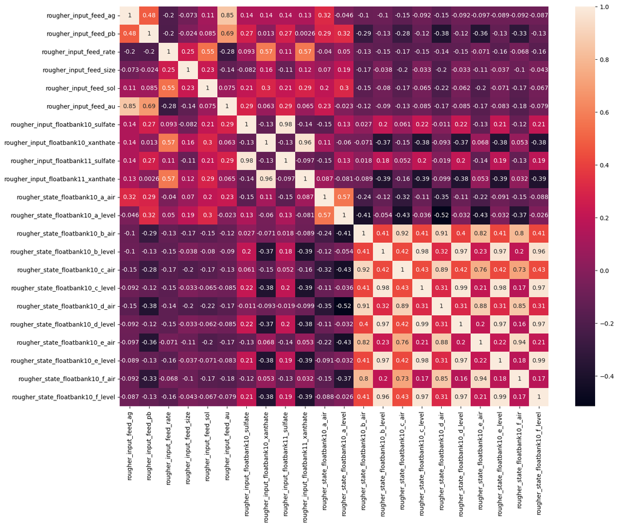

```python
# выведем диаграмму корреляции для этапа rougher
plt.figure(figsize=(16, 12))
sns.heatmap(data=X_train_rough.corr(), annot=True)
plt.show()
```

```python
X_train_rough.corr().loc[['rougher_input_floatbank11_sulfate', 'rougher_input_floatbank11_xanthate'],
                         ['rougher_input_floatbank10_sulfate', 'rougher_input_floatbank10_xanthate']]
```

|  | rougher_input_floatbank10_sulfate | rougher_input_floatbank10_xanthate |
| --- | --- | --- |
| rougher_input_floatbank11_sulfate | 0.98 | -0.13 |
| rougher_input_floatbank11_xanthate | -0.14 | 0.96 |

```python
X_train_rough.corr()[['rougher_state_floatbank10_c_level', 'rougher_state_floatbank10_d_level',
                     'rougher_state_floatbank10_e_level', 'rougher_state_floatbank10_f_level'
                     ]].sort_values(by='rougher_state_floatbank10_c_level', ascending=False).head(7)
```

|  | rougher_state_floatbank10_c_level | rougher_state_floatbank10_d_level | rougher_state_floatbank10_e_level | rougher_state_floatbank10_f_level |
| --- | --- | --- | --- | --- |
| rougher_state_floatbank10_c_level | 1.00 | 0.99 | 0.98 | 0.97 |
| rougher_state_floatbank10_d_level | 0.99 | 1.00 | 0.97 | 0.97 |
| rougher_state_floatbank10_b_level | 0.98 | 0.97 | 0.97 | 0.96 |
| rougher_state_floatbank10_e_level | 0.98 | 0.97 | 1.00 | 0.99 |
| rougher_state_floatbank10_f_level | 0.97 | 0.97 | 0.99 | 1.00 |
| rougher_state_floatbank10_c_air | 0.43 | 0.42 | 0.42 | 0.43 |
| rougher_state_floatbank10_b_air | 0.41 | 0.40 | 0.41 | 0.41 |

```python
# создадим список признаков для удаления на этапе флотации
collinear_columns_rough = ['rougher_input_floatbank11_sulfate', 'rougher_input_floatbank11_xanthate',
                           'rougher_state_floatbank10_c_level', 'rougher_state_floatbank10_d_level',
                           'rougher_state_floatbank10_e_level', 'rougher_state_floatbank10_f_level',
                          ]
```

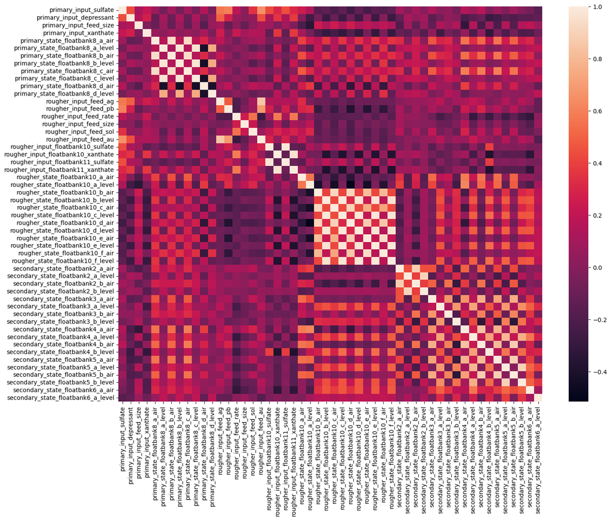

```python
# выведем диаграмму корреляции для этапа final
plt.figure(figsize=(16, 12))
sns.heatmap(data=X_train_final.corr(), annot=False)
plt.show()
```

```python
X_train_final.corr().loc[['primary_state_floatbank8_a_air', 'primary_state_floatbank8_a_level'],
                         ['primary_state_floatbank8_b_air', 'primary_state_floatbank8_b_level',
                          'primary_state_floatbank8_c_air', 'primary_state_floatbank8_c_level',
                         ]].sort_values(by='primary_state_floatbank8_b_air', ascending=False).head(10)
```

|  | primary_state_floatbank8_b_air | primary_state_floatbank8_b_level | primary_state_floatbank8_c_air | primary_state_floatbank8_c_level |
| --- | --- | --- | --- | --- |
| primary_state_floatbank8_a_air | 0.95 | 0.18 | 0.93 | 0.18 |
| primary_state_floatbank8_a_level | 0.12 | 0.98 | 0.16 | 0.96 |

```python
X_train_final.corr().loc[['secondary_state_floatbank2_a_air', 'secondary_state_floatbank2_a_level'],
                         ['secondary_state_floatbank2_b_air', 'secondary_state_floatbank2_b_level'
                     ]].sort_values(by='secondary_state_floatbank2_b_air', ascending=False).head()
```

|  | secondary_state_floatbank2_b_air | secondary_state_floatbank2_b_level |
| --- | --- | --- |
| secondary_state_floatbank2_a_air | 0.88 | 0.44 |
| secondary_state_floatbank2_a_level | 0.39 | 0.91 |

Вывод: на этапах primary и secondary также присутствуют сильно коррелирующие между собой признаки, характеризующие уровень жидкости и объем воздуха в различных флотационных установках. Удалим часть сильно коррелирующих признаков для этапов первичной и вторичной очистки.

```python
collinear_columns_final = ['rougher_input_floatbank11_sulfate', 'rougher_input_floatbank11_xanthate',
                           'rougher_state_floatbank10_c_level', 'rougher_state_floatbank10_d_level',
                           'rougher_state_floatbank10_e_level', 'rougher_state_floatbank10_f_level',
                           'primary_state_floatbank8_b_air', 'primary_state_floatbank8_b_level',
                           'primary_state_floatbank8_c_air', 'primary_state_floatbank8_c_level',
                           'secondary_state_floatbank2_b_air', 'secondary_state_floatbank2_b_level'
                          ]
```

```python
# удалим мультиколлинеарные признаки из обучающей и тестовой выборок для финального этапа
X_train_final = X_train_final.drop(collinear_columns_final, axis=1)
X_test_final = X_test_final.drop(collinear_columns_final, axis=1)
```

```python
print(X_train_final.shape)
print(X_test_final.shape)
```

```
(12434, 40)
(5229, 40)
```

```python
# удалим мультиколлинеарные признаки из обучающей и тестовой выборок для этапа флотации
X_train_rough = X_train_rough.drop(collinear_columns_rough, axis=1)
X_test_rough = X_test_rough.drop(collinear_columns_rough, axis=1)
```

```python
print(X_train_rough.shape)
print(X_test_rough.shape)
```

```
(12434, 16)
(5229, 16)
```

#### Масштабирование значений нормализацией.

Масштабируем значения обучающей и тестовой выборок нормализацией с помощью метода MinMaxScaler().

```python
# создадим функцию для масштабирования
def scale_X (X_train, X_test, columns):
    scaler = MinMaxScaler()
    scaler.fit(X_train)
    X_train[columns] = scaler.transform(X_train[columns])
    X_test[columns] = scaler.transform(X_test[columns])
```

```python
# масштабируем числовые признаки нормализацией значений для этапа флотации, выведем на экран минимум и максимум для проверки
columns = X_train_rough.columns
scale_X(X_train_rough, X_test_rough, columns)
display(X_train_rough.describe().loc[['min','max'],:])
display(X_test_rough.describe().loc[['min','max'],:])
```

|  | rougher_input_feed_ag | rougher_input_feed_pb | rougher_input_feed_rate | rougher_input_feed_size | rougher_input_feed_sol | rougher_input_feed_au | rougher_input_floatbank10_sulfate | rougher_input_floatbank10_xanthate | rougher_state_floatbank10_a_air | rougher_state_floatbank10_a_level | rougher_state_floatbank10_b_air | rougher_state_floatbank10_b_level | rougher_state_floatbank10_c_air | rougher_state_floatbank10_d_air | rougher_state_floatbank10_e_air | rougher_state_floatbank10_f_air |
| --- | --- | --- | --- | --- | --- | --- | --- | --- | --- | --- | --- | --- | --- | --- | --- | --- |
| min | 0.00 | 0.00 | 0.00 | 0.00 | 0.00 | 0.00 | 0.00 | 0.00 | 0.00 | 0.00 | 0.00 | 0.00 | 0.00 | 0.00 | 0.00 | 0.00 |
| max | 1.00 | 1.00 | 1.00 | 1.00 | 1.00 | 1.00 | 1.00 | 1.00 | 1.00 | 1.00 | 1.00 | 1.00 | 1.00 | 1.00 | 1.00 | 1.00 |

|  | rougher_input_feed_ag | rougher_input_feed_pb | rougher_input_feed_rate | rougher_input_feed_size | rougher_input_feed_sol | rougher_input_feed_au | rougher_input_floatbank10_sulfate | rougher_input_floatbank10_xanthate | rougher_state_floatbank10_a_air | rougher_state_floatbank10_a_level | rougher_state_floatbank10_b_air | rougher_state_floatbank10_b_level | rougher_state_floatbank10_c_air | rougher_state_floatbank10_d_air | rougher_state_floatbank10_e_air | rougher_state_floatbank10_f_air |
| --- | --- | --- | --- | --- | --- | --- | --- | --- | --- | --- | --- | --- | --- | --- | --- | --- |
| min | 0.17 | 0.04 | -0.00 | -0.02 | 0.04 | 0.17 | 0.00 | -0.00 | -0.02 | -0.02 | 0.33 | -0.35 | 0.23 | 0.32 | 0.38 | 0.00 |
| max | 0.99 | 0.97 | 0.99 | 0.81 | 1.11 | 1.05 | 0.67 | 0.92 | 0.92 | 1.02 | 0.93 | 1.00 | 0.63 | 0.97 | 0.75 | 0.77 |

```python
# масштабируем числовые признаки нормализацией значений для финального этапа, выведем на экран минимум и максимум для проверки
columns = X_train_final.columns
scale_X(X_train_final, X_test_final, columns)

display(X_train_final.describe().loc[['min','max'],:])
display(X_test_final.describe().loc[['min','max'],:])
```

|  | primary_input_sulfate | primary_input_depressant | primary_input_feed_size | primary_input_xanthate | primary_state_floatbank8_a_air | primary_state_floatbank8_a_level | primary_state_floatbank8_d_air | primary_state_floatbank8_d_level | rougher_input_feed_ag | rougher_input_feed_pb | rougher_input_feed_rate | rougher_input_feed_size | rougher_input_feed_sol | rougher_input_feed_au | rougher_input_floatbank10_sulfate | rougher_input_floatbank10_xanthate | rougher_state_floatbank10_a_air | rougher_state_floatbank10_a_level | rougher_state_floatbank10_b_air | rougher_state_floatbank10_b_level | rougher_state_floatbank10_c_air | rougher_state_floatbank10_d_air | rougher_state_floatbank10_e_air | rougher_state_floatbank10_f_air | secondary_state_floatbank2_a_air | secondary_state_floatbank2_a_level | secondary_state_floatbank3_a_air | secondary_state_floatbank3_a_level | secondary_state_floatbank3_b_air | … |
| --- | --- | --- | --- | --- | --- | --- | --- | --- | --- | --- | --- | --- | --- | --- | --- | --- | --- | --- | --- | --- | --- | --- | --- | --- | --- | --- | --- | --- | --- | --- |
| min | 0.00 | 0.00 | 0.00 | 0.00 | 0.00 | 0.00 | 0.00 | 0.00 | 0.00 | 0.00 | 0.00 | 0.00 | 0.00 | 0.00 | 0.00 | 0.00 | 0.00 | 0.00 | 0.00 | 0.00 | 0.00 | 0.00 | 0.00 | 0.00 | 0.00 | 0.00 | 0.00 | 0.00 | 0.00 | … |
| max | 1.00 | 1.00 | 1.00 | 1.00 | 1.00 | 1.00 | 1.00 | 1.00 | 1.00 | 1.00 | 1.00 | 1.00 | 1.00 | 1.00 | 1.00 | 1.00 | 1.00 | 1.00 | 1.00 | 1.00 | 1.00 | 1.00 | 1.00 | 1.00 | 1.00 | 1.00 | 1.00 | 1.00 | 1.00 | … |

|  | primary_input_sulfate | primary_input_depressant | primary_input_feed_size | primary_input_xanthate | primary_state_floatbank8_a_air | primary_state_floatbank8_a_level | primary_state_floatbank8_d_air | primary_state_floatbank8_d_level | rougher_input_feed_ag | rougher_input_feed_pb | rougher_input_feed_rate | rougher_input_feed_size | rougher_input_feed_sol | rougher_input_feed_au | rougher_input_floatbank10_sulfate | rougher_input_floatbank10_xanthate | rougher_state_floatbank10_a_air | rougher_state_floatbank10_a_level | rougher_state_floatbank10_b_air | rougher_state_floatbank10_b_level | rougher_state_floatbank10_c_air | rougher_state_floatbank10_d_air | rougher_state_floatbank10_e_air | rougher_state_floatbank10_f_air | secondary_state_floatbank2_a_air | secondary_state_floatbank2_a_level | secondary_state_floatbank3_a_air | secondary_state_floatbank3_a_level | secondary_state_floatbank3_b_air | … |
| --- | --- | --- | --- | --- | --- | --- | --- | --- | --- | --- | --- | --- | --- | --- | --- | --- | --- | --- | --- | --- | --- | --- | --- | --- | --- | --- | --- | --- | --- | --- |
| min | 0.06 | 0.01 | 0.49 | 0.01 | 0.40 | -0.65 | 0.32 | -0.00 | 0.17 | 0.04 | -0.00 | -0.02 | 0.04 | 0.17 | 0.00 | -0.00 | -0.02 | -0.02 | 0.33 | -0.35 | 0.23 | 0.32 | 0.38 | 0.00 | 0.06 | 0.02 | -0.29 | -0.00 | -0.39 | … |
| max | 1.06 | 1.00 | 1.54 | 1.63 | 0.85 | 1.99 | 0.79 | 0.93 | 0.99 | 0.97 | 0.99 | 0.81 | 1.11 | 1.05 | 0.67 | 0.92 | 0.92 | 1.02 | 0.93 | 1.00 | 0.63 | 0.97 | 0.75 | 0.77 | 0.61 | 0.74 | 0.88 | 0.80 | 0.88 | … |

Вывод: признаки масштабированы нормализацией значений от 0 до 1.

## Исследовательский анализ данных.

Изучим изменение концентрации металлов на различных этапах на основе полного набора данных.

### Динамика концентрации металлов (Au, Ag, Pb) на различных этапах очистки.

```python
# создадим списки признаков с концентрацией серебра, свинца и золота на соответствующих этапах
con_ag = ['rougher_input_feed_ag', 'rougher_output_ag', \
          'primary_output_ag', 'final_output_ag']
con_pb = ['rougher_input_feed_pb', 'rougher_output_pb', \
          'primary_output_pb', 'final_output_pb']
con_au = ['rougher_input_feed_au', 'rougher_output_au', \
          'primary_output_au', 'final_output_au']
```

```python
# создадим функцию для построения графиков плотности распределения
def graph_concentrate (columns, metals):
    plt.figure(figsize=(14, 10))
    sns.kdeplot(data=df_full[columns], bw_adjust=0.5)
    plt.grid(which='both', axis='both')
    plt.title(f'Изменение распределения концентрации {metals}', y=1.05)
    plt.ylabel('Плотность значений')
    plt.xlabel('Концентрация')
    plt.show()
```

#### Динамика концентрации золота.

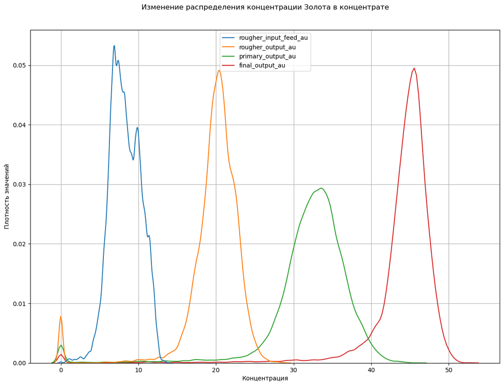

```python
# построим диаграммы концентрации Золота в концентрате
graph_concentrate(con_au, 'Золота в концентрате')
```

**Вывод:** Технологический процесс явно акцентирован на увеличении концентрации именно золота. В среднем концентрация золота поэтапно повышается с 8% в исходной смеси, до 20% - после флотации, до 33% - после первичной очистки и до 45% в финальном концентрате. При этом, распределение значений выглядит нормальным, с четко выраженным пиком.

#### Динамика концентрации серебра.

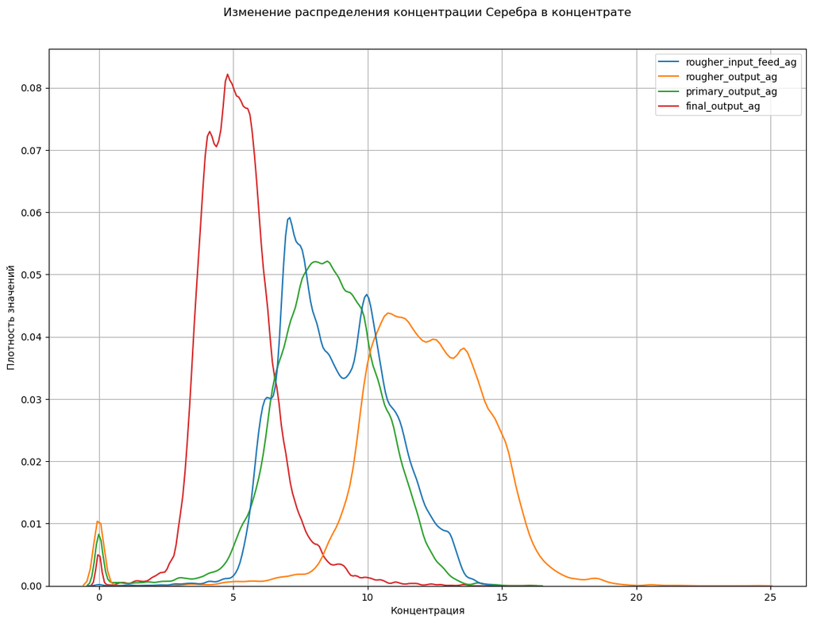

```python
# построим диаграммы концентрации серебра в концентрате и отвальных хвостах
graph_concentrate(con_ag, 'Серебра в концентрате')
```

**Вывод:** Концентрация серебра в концентрате после этапа флотации повышается в среднем с 7% в исходной смеси до 12%. Однако после очистки, концентрация снижается в среднем до 5% в конечном концентрате.

Построим диаграммы распределения концентрации серебра в отвальных хвостах.

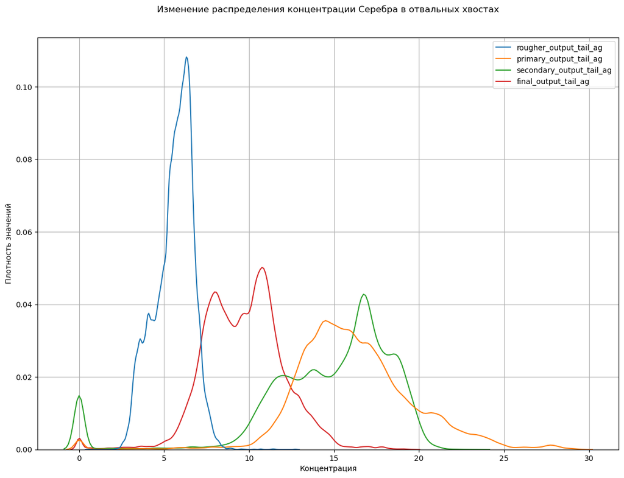

```python
tail_ag = ['rougher_output_tail_ag', 'primary_output_tail_ag', 'secondary_output_tail_ag', 'final_output_tail_ag']
graph_concentrate(tail_ag, 'Серебра в отвальных хвостах')
```

**Вывод:** Концентрация серебра в отвальных хвостах в противовес концентрату повышается с 7% после этапа флотации, до 15-16% на этапах очистки, и снижается до 9% в конечных отвальных хвостах. То есть, концентрация серебра в отвальных хвостах на этапах очистки в среднем выше, чем в концентратах.

Такое расхождение, вероятно, возникает в связи с особенностью технологического процесса, настроенного на увеличение концентрации именно золота, а также отличия физико-химических свойств серебра от свинца и золота.

#### Динамика концентрации свинца.

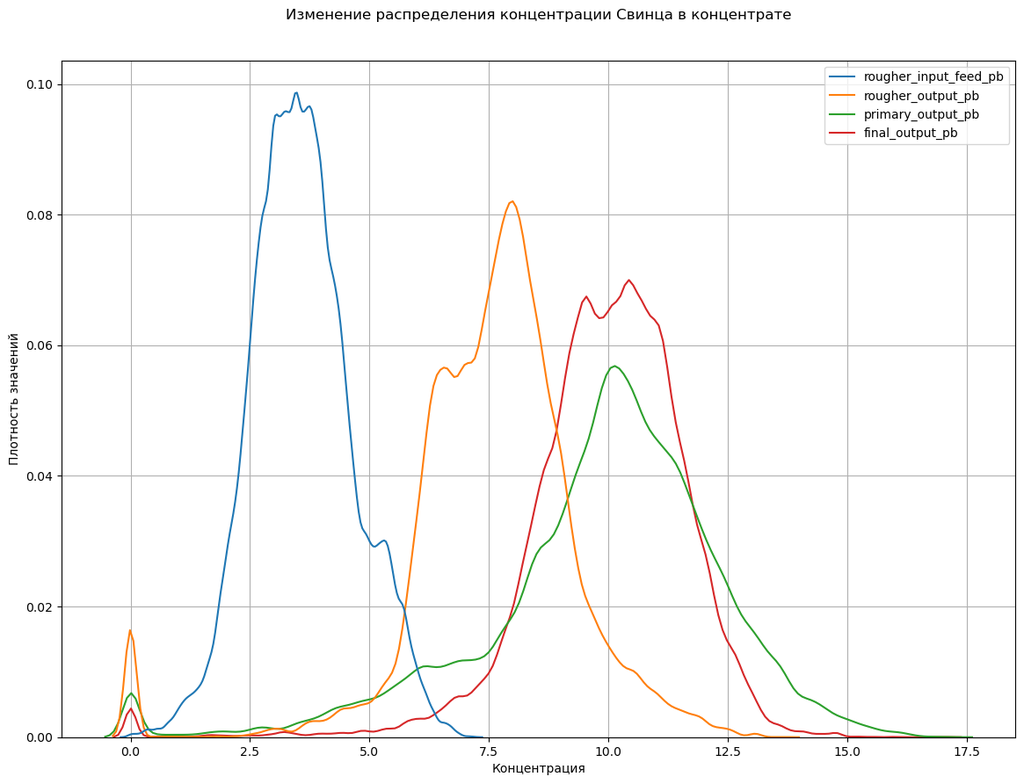

```python
# построим диаграммы концентрации свинца в концентрате
graph_concentrate(con_pb, 'Свинца в концентрате')
```

**Вывод:** Концентрация свинца в среднем увеличивается с 3% в исходной смеси, до 8% - после флотации и до 11% после первичной очистки и в финальном продукте. В результате этапов первичной и вторичной очистки средняя концентрация не увеличивается в финальном концентрате, однако улучшается ее распределение - значения более плотно распределены вокруг среднего, а количество значений вдали от среднего меньше.

### Сравнение распределения размеров гранул сырья на обучающей и тестовой выборках.

Сравним распределения в тестовой и обучающей выборках, т.к. сильное отличие может привести к неправильной оценке моделей.

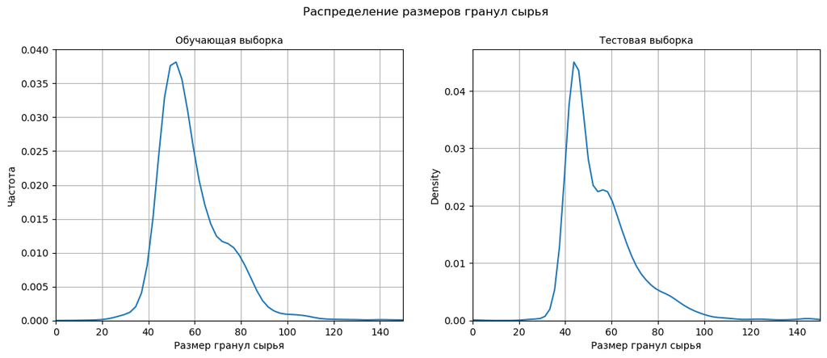

|  | Обучающая | Тестовая |
| --- | --- | --- |
| count | 14,005.00 | 5,289.00 |
| mean | 60.11 | 55.95 |
| std | 22.42 | 19.08 |
| min | 9.66 | 0.05 |
| 1% | 35.31 | 38.47 |
| 5% | 42.44 | 41.18 |
| 25% | 48.97 | 43.91 |
| 50% | 55.37 | 50.84 |
| 75% | 66.08 | 62.43 |
| 95% | 85.01 | 85.66 |
| 99% | 125.21 | 111.94 |
| max | 484.97 | 392.49 |

```python
# построим диаграммы плотности распределения размеров гранул
fig, (ax1, ax2) = plt.subplots(1, 2, figsize=(14, 5))

sns.kdeplot(data=df_train['rougher_input_feed_size'], ax=ax1)
ax1.set_title('Обучающая выборка', fontsize='medium')
ax1.set_xlim(0, 150)
ax1.set_ylabel('Частота')
ax1.set_xlabel('Размер гранул сырья')

sns.kdeplot(data=df_test['rougher_input_feed_size'], ax=ax2)
ax2.set_title('Тестовая выборка', fontsize='medium')
ax2.set_xlabel('Размер гранул сырья')
ax2.set_xlim(0, 150)

for ax in ax1, ax2:
    ax.grid(True)

fig.suptitle('Распределение размеров гранул сырья', fontsize='large', y=1)
plt.show()

display(pd.DataFrame(data={'Обучающая':df_train['rougher_input_feed_size'].describe(percentiles=[.01,.05,.25,.50,.75,.95,.99]),
                           'Тестовая':df_test['rougher_input_feed_size'].describe(percentiles=[.01,.05,.25,.50,.75,.95,.99])},
                     index=df_train['rougher_input_feed_size'].describe(percentiles=[.01,.05,.25,.50,.75,.95,.99]).index,
                     columns=['Обучающая', 'Тестовая']))
```

**Вывод:** Распределение размеров гранул сырья в целом незначительно отличается в обучающей и тестовой выборке.

### Исследование суммарной концентрации всех металлов на разных стадиях: в сырье, в черновом и финальном концентратах.

```python
# рассчитаем суммарную концентрацию серебра, свинца и золота в сырье, в черновом и финальном концентратах и выведем на экран
# для проверки
df_full['rougher_input_feed_all'] = df_full[['rougher_input_feed_ag', 'rougher_input_feed_pb',
                                             'rougher_input_feed_au']].sum(axis=1)
df_full['rougher_output_all'] = df_full[['rougher_output_ag', 'rougher_output_pb', 'rougher_output_au']].sum(axis=1)
df_full['final_output_all'] = df_full[['final_output_ag', 'final_output_pb', 'final_output_au']].sum(axis=1)

display(df_full[['rougher_input_feed_ag', 'rougher_input_feed_pb', 'rougher_input_feed_au', 'rougher_input_feed_all']].head(2))
display(df_full[['rougher_output_ag', 'rougher_output_pb', 'rougher_output_au', 'rougher_output_all']].head(2))
display(df_full[['final_output_ag', 'final_output_pb', 'final_output_au', 'final_output_all']].head(2))
```

| date | rougher_input_feed_ag | rougher_input_feed_pb | rougher_input_feed_au | rougher_input_feed_all |
| --- | --- | --- | --- | --- |
| 2016-01-15 00:00:00 | 6.10 | 2.28 | 6.49 | 14.87 |
| 2016-01-15 01:00:00 | 6.16 | 2.27 | 6.48 | 14.91 |

| date | rougher_output_ag | rougher_output_pb | rougher_output_au | rougher_output_all |
| --- | --- | --- | --- | --- |
| 2016-01-15 00:00:00 | 11.50 | 7.10 | 19.79 | 38.40 |
| 2016-01-15 01:00:00 | 11.62 | 7.28 | 20.05 | 38.95 |

| date | final_output_ag | final_output_pb | final_output_au | final_output_all |
| --- | --- | --- | --- | --- |
| 2016-01-15 00:00:00 | 6.06 | 9.89 | 42.19 | 58.14 |
| 2016-01-15 01:00:00 | 6.03 | 9.97 | 42.70 | 58.70 |

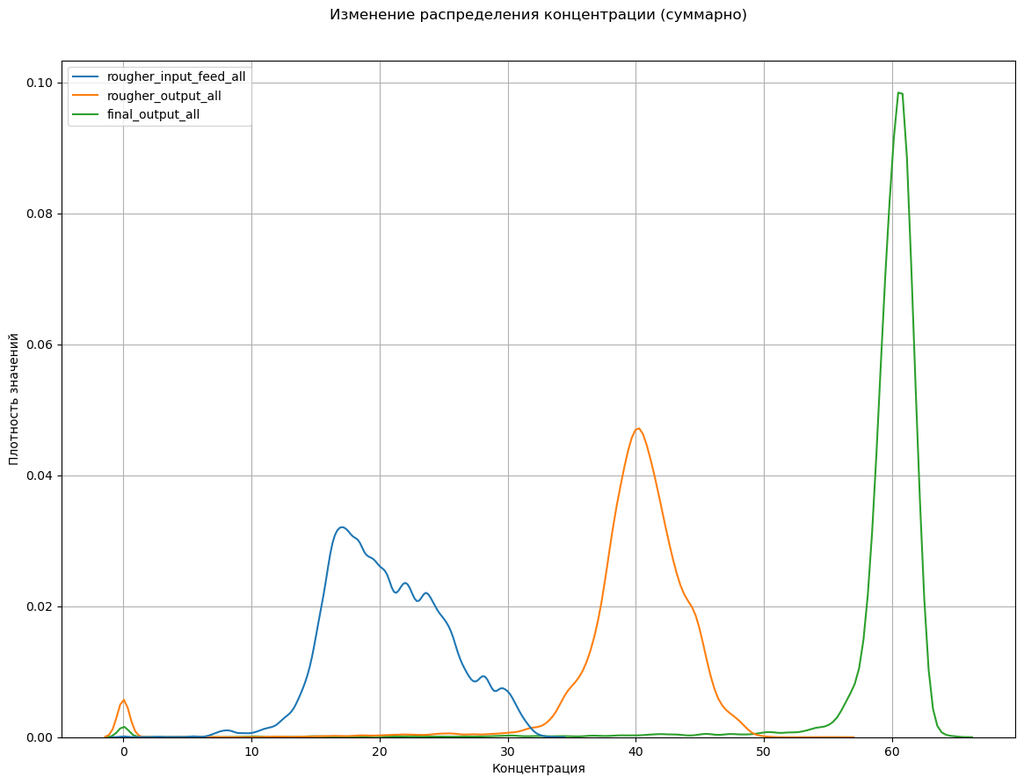

```python
graph_concentrate(['rougher_input_feed_all', 'rougher_output_all', 'final_output_all'
                  ],
                  '(суммарно)')
```

**Вывод:** В среднем суммарная концентрация металлов поэтапно возрастает с 20% в исходной смеси, до 40% в черновом концентрате после флотации и до 61% в итоговом концентрате, при этом разброс значений вокруг среднего с каждым этапом становится меньше, что может характеризовать определенную эффективность производства.

Также заметим, что в суммарных концентрациях присутствуют околонулевые значения, что может говорить об ошибочных данных. Изучим дополнительно околонулевые значения концентрации металлов в обучающей выборке.

```python
# выведем на экран распределения концентрации металлов в обучающей выборке
df_train_feat[['rougher_input_feed_ag', 'rougher_input_feed_pb',
               'rougher_input_feed_au']].describe(percentiles=[.0005,.05,.25,.50,.75,.95,.99])
```

|  | rougher_input_feed_ag | rougher_input_feed_pb | rougher_input_feed_au |
| --- | --- | --- | --- |
| count | 12,434.00 | 12,434.00 | 12,434.00 |
| mean | 8.58 | 3.52 | 7.88 |
| std | 1.89 | 1.08 | 1.85 |
| min | 0.01 | 0.01 | 0.01 |
| 0.05% | 1.31 | 0.13 | 1.33 |
| 5% | 6.15 | 1.90 | 5.20 |
| 25% | 7.13 | 2.77 | 6.61 |
| 50% | 8.13 | 3.42 | 7.63 |
| 75% | 9.97 | 4.23 | 9.02 |
| 95% | 12.05 | 5.45 | 11.38 |
| 99% | 13.14 | 6.16 | 12.11 |
| max | 14.60 | 7.14 | 13.13 |

Вывод: околонулевые значения присутствуют.

```python
# выведем строки обучающей выборки, в которых концентрация меньше 1.5
threshold = 1.5
df_train_feat.query('rougher_input_feed_ag < @threshold')[
    ['rougher_input_feed_ag', 'rougher_input_feed_pb', 'rougher_input_feed_au']]
```

| date | rougher_input_feed_ag | rougher_input_feed_pb | rougher_input_feed_au |
| --- | --- | --- | --- |
| 2016-04-21 00:00:00 | 1.12 | 0.41 | 1.03 |
| 2018-03-12 03:00:00 | 0.01 | 0.01 | 0.01 |
| 2018-03-12 04:00:00 | 0.01 | 0.01 | 0.01 |
| 2018-03-12 05:00:00 | 0.01 | 0.01 | 0.01 |
| 2018-03-12 06:00:00 | 0.01 | 0.01 | 0.01 |
| 2018-03-12 07:00:00 | 0.01 | 0.01 | 0.01 |
| 2018-03-15 17:00:00 | 1.23 | 0.61 | 1.27 |

Вывод: 12 марта 2018 года присутствуют ошибочные данные измерений, т.к. входящие концетрации трех металлов близки к нулю одновременно. Удалим данные строки из обучающих выборок.

```python
# сохраним индексы строк для удаления
zeros_drop = df_train_feat.query('rougher_input_feed_ag < 1 and rougher_input_feed_pb < 1 and rougher_input_feed_au < 1').index
```

```python
zeros_drop
```

```
DatetimeIndex(['2018-03-12 03:00:00', '2018-03-12 04:00:00',
               '2018-03-12 05:00:00', '2018-03-12 06:00:00',
               '2018-03-12 07:00:00'],
              dtype='datetime64[ns]', name='date', freq=None)
```

```python
# удалим строки с сохраненными индексами из обучающих выборок
X_train_rough = X_train_rough.drop(zeros_drop)
y_train_final = y_train_final.drop(zeros_drop)

y_train_rough = y_train_rough.drop(zeros_drop)
X_train_final = X_train_final.drop(zeros_drop)
```

```python
# проверим удаление
try:
    X_train_rough[zeros_drop]
except:
    print('Строки удалены из обучающей выборки для этапа флотации')

try:
    y_train_rough[zeros_drop]
except:
    print('Строки удалены из целевого признака для этапа флотации')

try:
    X_train_final[zeros_drop]
except:
    print('Строки удалены из обучающей выборки для финального этапа')

try:
    y_train_final[zeros_drop]
except:
    print('Строки удалены из целевого признака для финального этапа')
```

```
Строки удалены из обучающей выборки для этапа флотации
Строки удалены из целевого признака для этапа флотации
Строки удалены из обучающей выборки для финального этапа
Строки удалены из целевого признака для финального этапа
```

## Разработка прототипа модели машинного обучения.

### Создадим функцию для вычисления итоговой sMAPE.

```python
def calc_smape (y, y_pred):
    return 1/len(y) * sum(2 * abs(y-y_pred) / (abs(y) + abs(y_pred))) * 100
```

```python
def total_smape(smape_rough, smape_final):
    total_smape = smape_rough * 0.25 + smape_final * 0.75
    return total_smape
```

### Обучение разных моделей и оценка их качества кросс-валидацией. Выбор лучшей модели и проверка её на тестовой выборке.

```python
# создадим метрику для оценки моделей в процессе кросс-валидации
smape_score = make_scorer(calc_smape, greater_is_better=False)
```

```python
# выведем итоговые размеры выборок с признаками для проверки
print(X_train_rough.shape, X_train_final.shape, y_train_rough.shape, y_train_final.shape)
print(X_test_rough.shape, X_test_final.shape, y_test_rough.shape, y_test_final.shape)
```

```
(12429, 16) (12429, 40) (12429,) (12429,)
(5229, 16) (5229, 40) (5229,) (5229,)
```

```python
# создадим функцию для обучения моделей с помощью методов GridSearchCV и RandomizedSearchCV со встроенной оценкой
# методом кросс-валидации

def validate_model (search, model, grid_param):

    if search != 'random':

        model_rough = model
        grid_rough = GridSearchCV(model_rough,
                                  param_grid=grid_param,
                                  scoring=smape_score,
                                  n_jobs=-1
                                 )
        grid_rough.fit(X_train_rough, y_train_rough)

        model_final = model
        grid_final = GridSearchCV(model_final,
                                  param_grid=grid_param,
                                  scoring=smape_score,
                                  n_jobs=-1
                                 )
        grid_final.fit(X_train_final, y_train_final)

        tot_smape = total_smape(- grid_rough.best_score_, - grid_final.best_score_)

    else:
        model_rough = model
        grid_rough = RandomizedSearchCV(model_rough,
                                        param_distributions=grid_param,
                                        scoring=smape_score,
                                        n_jobs=-1,
                                        random_state=12345
                                       )
        grid_rough.fit(X_train_rough, y_train_rough)

        model_final = model
        grid_final = RandomizedSearchCV(model_final,
                                        param_distributions=grid_param,
                                        scoring=smape_score,
                                        n_jobs=-1,
                                        random_state=12345
                                       )
        grid_final.fit(X_train_final, y_train_final)

        tot_smape = total_smape(- grid_rough.best_score_, - grid_final.best_score_)


    return grid_rough, grid_final, tot_smape
```

```python
%%time
# обучим и оценим молель LinearRegression
model_lr_rough, model_lr_final, best_lr_smape = validate_model('grid', LinearRegression(), {})
```

```
Wall time: 3.22 s
```

```python
%%time
# подберем гиперпараметры, обучим и оценим модель Lasso
model_lasso_rough, model_lasso_final, best_lasso_smape = validate_model('grid', Lasso(),
                                                                        {'alpha': np.arange(0.01, 0.15, 0.01)})
```

```
Wall time: 1.45 s
```

```python
%%time
# подберем гиперпараметры, обучим и оценим молель DecisionTreeRegressor
model_dtr_rough, model_dtr_final, best_dtr_smape = validate_model('random', DecisionTreeRegressor(random_state=12345),
                                                                        {'splitter': ('best', 'random'),
                                                                         'max_depth': range(1, 20),
                                                                         'min_samples_split': range(2, 4),
                                                                         'min_samples_leaf': range(1, 3),
                                                                        }
                                                                       )
```

```
Wall time: 3 s
```

```python
%%time
# подберем гиперпараметры, обучим и оценим молель GradientBoostingRegressor
# время обучения около 7 минут
model_gbr_rough, model_gbr_final, best_gbr_smape = validate_model('random', GradientBoostingRegressor(random_state=12345),
                                                                  {'n_estimators': range(30, 80, 10),
                                                                   'max_depth': range(1, 5),
                                                                   'min_samples_split': range(2, 4),
                                                                   'min_samples_leaf': range(1, 3),
                                                                  }
                                                                 )
```

```
Wall time: 1min 21s
```

```python
# выведем результаты лучших значений итоговой метрики smape для исследованных моделей в процессе кросс-валидации
# и подбора гиперпараметров
results = pd.DataFrame({'Best total sMAPE':[best_lr_smape, best_lasso_smape, best_dtr_smape, best_gbr_smape]},
                       index=['LinearRegression', 'Lasso', 'DecisionTreeRegressor', 'GradientBoostingRegressor'])
results.sort_values(by='Best total sMAPE')
```

|  | Best total sMAPE |
| --- | --- |
| GradientBoostingRegressor | 7.74 |
| Lasso | 8.09 |
| DecisionTreeRegressor | 8.47 |
| LinearRegression | 9.18 |

Вывод: лучшую итоговую метрику sMAPE продемонстрировала модель GradientBoostingRegressor, т.е. симметричная средняя процентная ошибка составила 7,74 % по шкале от 0 до 200 %.

Проверим модель на тестовой выборке и сравним с моделью DummyRegressor.

```python
# создадим функцию для проверки модели на тестовой выборке
def test_model (model_rough, model_final):
    y_pred_test_rough = model_rough.predict(X_test_rough)
    y_pred_test_final = model_final.predict(X_test_final)

    smape_r = calc_smape(y_test_rough, y_pred_test_rough)
    smape_f = calc_smape(y_test_final, y_pred_test_final)
    score = 0.25 * smape_r + 0.75 * smape_f
    return score
```

```python
# подберем лучшие гиперпарамтеры и обучим модель DummyRegressor
model_dummy_rough, model_dummy_final, best_dummy_smape = validate_model('grid', DummyRegressor(),
                                                                        {'strategy':('mean', 'median', 'quantile'),
                                                                         'quantile': np.arange(0, 1, 0.05)
                                                                        }
                                                                       )
```

```python
# проверим модели GradientBoostingRegressor и DummyRegressor на тестовой выборке и выведем результат на экран
test_results = pd.DataFrame({'Best sMAPE':[best_gbr_smape, test_model(model_gbr_rough, model_gbr_final), test_model(model_dummy_rough, model_dummy_final)]},
                       index=['GradientBoostingRegressor cross-valid', 'GradientBoostingRegressor TEST', 'DummyRegressor TEST'])
```

```python
# выведем на экран результат проверки на тестовой выборке
display(test_results)
```

|  | Best sMAPE |
| --- | --- |
| GradientBoostingRegressor cross-valid | 7.74 |
| GradientBoostingRegressor TEST | 8.04 |
| DummyRegressor TEST | 9.04 |

Вывод: Метрика лучшей модели GradientBoostingRegressor на тестовой выборке ухудшилась незначительно и составила 8,04 %, при этом оставаясь лучше метрики модели DummyRegressor. Таким образом, можно рекомендовать лучшую модель GradientBoostingRegressor для оценки целесообразности запуска производств.

## Общий вывод.

В рамках данного проекта были исследованы четыре модели машинного обучения: LinearRegression, DecisionTreeRegressor, Lasso и GradientBoostingRegressor. Подбор гиперпараметров и оценка моделей производилась методом кросс-валидации (GridSearchCV, RandomizedSearchCV).

При подготовке данных к моделированию было изучено наличие пропусков данных, произведено масштабирование признаков методом нормализации значений. Произведена проверка правильности расчета целевых признаков (параметра recovery для этапов rougher и final). Проверено соответствие данных в обучающей и тестовой выборках исходному набору данных.

Изучено различие признаков в обучающей и тестовой выборке, произведено разделение выборок по принципу наличия признаков, соответствующих этапу флотации и финальному концентрату. Выделены значения целевых признаков для тестовой выборки из исходного набора данных.

Изучена динамика распределения концетрации металлов на разных этапах очистки, а также суммарной концентрации металлов. Произведено сравнение распределения размеров гранул в обучающей и тестовой выборке.

Исследование позволило сделать **следующие наблюдения**:

**1)** Технологический процесс явно акцентирован на увеличении концентрации именно золота. В среднем концентрация золота поэтапно повышается с 8% в исходной смеси, до 20% - после флотации, до 33% - после первичной очистки и до 45% в финальном концентрате. При этом, распределение значений выглядит нормальным, с четко выраженным пиком.

**2)** Концентрация серебра в концентрате после этапа флотации повышается в среднем с 7% в исходной смеси до 12%. Однако после очистки, концентрация снижается в среднем до 5% в конечном концентрате.

Концентрация серебра в отвальных хвостах в противовес концентрату повышается с 7% после этапа флотации, до 15-16% на этапах очистки, и снижается до 9% в конечных отвальных хвостах. То есть, концентрация серебра в отвальных хвостах на этапах очистки в среднем выше, чем в концентратах.

Такое расхождение, вероятно, возникает в связи с особенностью технологического процесса, настроенного на увеличение концентрации именно золота, а также отличия физико-химических свойств серебра от свинца и золота.

**3)** Концентрация свинца в среднем увеличивается с 3% в исходной смеси, до 8% - после флотации и до 11% после первичной очистки и в финальном продукте. В результате этапов первичной и вторичной очистки средняя концентрация не увеличивается в финальном концентрате, однако улучшается ее распределение - значения более плотно распределены вокруг среднего, а количество значений вдали от среднего меньше.

**4)** В среднем суммарная концентрация металлов поэтапно возрастает с 20% в исходной смеси, до 40% в черновом концентрате после флотации и до 61% в итоговом концентрате, при этом разброс значений вокруг среднего с каждым этапом становится меньше, что может характеризовать определенную эффективность производства.

**5)** В процессе подбора гиперпараметров и оценки моделей кросс-валидацией, модели продемонстрировали следующие значения итоговой метрики sMAPE по шкале от 0 до 200%: GradientBoostingRegressor 7.74%, Lasso 8.09%, DecisionTreeRegressor 8.47%, LinearRegression 9.18%.

**6)** Метрика лучшей модели GradientBoostingRegressor на тестовой выборке ухудшилась незначительно и составила 8,04%, при этом оставаясь лучше метрики модели DummyRegressor (9,04%).

Таким образом, можно рекомендовать лучшую модель **GradientBoostingRegressor** для оценки целесообразности запуска производств.